# Ficha de Información Metropolitana

Universidad Autónoma Metropolitnana

Lic. Martínez Rodriguez, Alvaro[^1]

Lic. Pérez Victorino, Leonardo[^2]

La ficha de información metropolitana es una herramienta valiosa para la planificación territorial en zonas metropolitanas (ZM). Proporciona información censal en diferentes formatos, como gráficos, tablas y mapas, tanto de los Censos de Población y Vivienda, 2020 (CPV2020) como de los Censos Económicos de 1999, 2004, 2009, 2014 y 2019. Ambos publicados por el Instituto Nacional de Estadística y Geografía (INEGI).

## Información general de la Zona Metropolitana de Minatitlán

Según (Sedatu 2018), la zona metropolitana se define como un área urbana que consta de una ciudad principal y su zona conurbada. Las zonas metropolitanas se caracterizan por tener una alta densidad de población y estar interconectadas por vías de transporte y comunicación. La zona metropolitana de Minatitlán, se localiza en Veracruz de Ignacio de la Llave. y esta compuesta por 6 municipios, que se muestran a continuación:

| Nombre | Clave |
| --- | --- |
| Cosoleacaque | 30048 |
| Chinameca | 30059 |
| Jáltipan | 30089 |
| Minatitlán | 30108 |
| Oteapan | 30120 |
| Zaragoza | 30199 |

Municipios de la zona metropolitana

Además, se presenta un mapa de la zona metropolitana:

[interactive chart not shown]

## Información sociodemográfica

La estructura de población de la zona metropolitana de Minatitlán se presenta en la una piramide poblacional ya que permite obtener una visión general de la distribución de la población por género y edad:

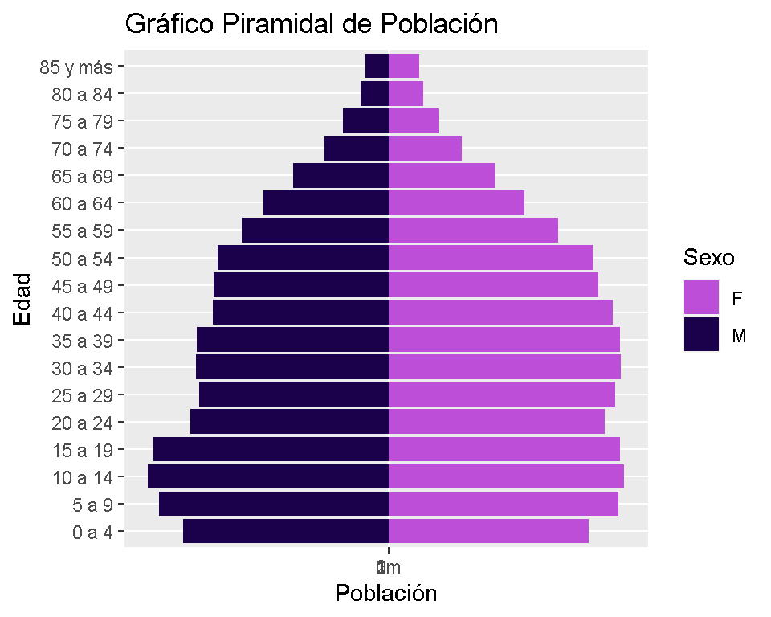

En el siguiente mapa se observa como se distribuye la población sobre la región:

[interactive chart not shown]

### Grupos de población

- Población total respecto al país: 0%. Este valor indica el peso poblacional de la zona metropolitana en relación con la población total de México.
- Población Masculina: 48%
- Población Femenina: 52%
- Relación M-F: 90.607. Este valor indica la proporción de hombres por cada mujer en la zona metropolitana.

### Socioeconómicos

La población en terminos de la poblacioón economicamente activa esta descrita por:

- Porcentaje de población de 12 años y más económicamente activa: 48%
- Porcentaje de población de 12 años y más no económicamente activa: 33% `

### Educación

La educación de la zona metropolitana esta caracterizada por los siguientes estadísticos:

- Porcentaje de población de 15 años y más sin escolaridad:5%
- Porcentaje de población de 15 años y más con al menos un grado aprobado en primaria: 67%
- Porcentaje de población de 15 años y más con educación básica completa: 15%
- Porcentaje de población de 15 años y más con secundaria o equivalente incompleta:2%
- Porcentaje de población de 18 años y más con al menos un grado aprobado en educación media superior: 32%

### Salud

La situación de la afiliación a algún servico de salud es la siguiente:

- Porcentaje de población afiliada a servicios de salud: 73%
- Población sin afiliación a servicios de salud:97509

### Indicadores de desarrollo

Finalmente se presentan tres indicadores de desarrollo; los índices son: índice de Desarrollo Humano (IDH), Índice de Marginación (IM) e Índice de Rezago Social (IRS).

IDH es un indicador elaborado por el Programa de Naciones Unidas para el Desarrollo (PNUD), este busca medir la calidad de vida, así como el progreso socioeconómico de cada entidad y municipio; El cálculo del Índice de Desarrollo Humano se realiza a partir de las tres variables: esperanza de vida, educación e ingreso per cápita.

- Muy Alto - IDH mayor de 1.
- Alto - IDH entre 0.80 a 1.
- Medio - IDH entre 0.50 y 0.80.
- Bajo - IDH entre 0 y 0.50
- Muy Bajo - IDH menores a 0.
- El promedio del IDH en 2020 para la zona metropolitana es de 0.717 según datos del PNUD.

El IM es un índice construido por el consejo Nacional de Población (CONAPO). Este índice considera 4 dimensiones estructurales para su construcción: vivienda, ingreso, educación y distribución de la población. El indice se puede ubicar en 5 estratos designados por la ténica de estratificación de Dalenius-Hodges..

Por último, el IRS es construido por el Consejo Nacional de Evaluación de la Política de Desarrollo Social, CONEVAL, este índice incorpora indicadores de educación, de acceso a servicios de salud, de servicios básicos y tiene como finalidad ordenar los municipios según sus carencias sociales. Este índice, al igual que el IM, se clasifica en cinco estratos.

## Datos económicos.

Con base en la información de los subsectores de los 21 sectores principales de la clasificación del SCIAN, extraída de los Censos Económicos del INEGI durante el periodo de 1998-2018, se ha llevado a cabo la agrupación de los datos de cada municipio que pertenece a una zona metropolitana en cinco grandes sectores: Primarios, Construcción, Manufactura, Comercio y Servicios. Esta clasificación se basa en la metodología proporcionada por el INEGI. Se utilizaron las siguientes variables:

- Unidades económicas (UE) [número de unidades]
- Activiso fijos totales (AF) [miles de pesos a precios corrientes]
- Formación bruta de capital fijo (FB) [miles de pesos a precios corrientes]
- Producción bruta total (PB) [miles de pesos a precios corrientes]
- Personal ocupado total (PO) [número de personas]
- Total de remuneraciones (RE) [miles de pesos a precios corrientes]
- Valor agregado censal bruto (VA) [miles de pesos a precios corrientes]

Posteriormente, se replica la metodología utilizada por García y Carranco (2008) para estimar los coeficientes de participación relativa (PR), de localización de la actividad económica (QL), Hirschman-Herfindahl (HH) e Inverso de Hirschman-Herfindahl (IHH).

$PR_ij$=$X_ij/X_in$

$QL_ij$=$(X_ij⁄X_j )/(X_in⁄X_n)$

$HH_ij$=$X_ij/X_in - X_j/X_n$

$IHH_ij$=$1/(X_ij/X_in - X_j/X_n)$

Donde:

### Cifras brutas

#### 1999

##### UE

| Clave | Municipio | Primarios | Construcción | Manufactura | Comercio | Servicios |
| --- | --- | --- | --- | --- | --- | --- |
| 30048 | Cosoleacaque | 45 | 0 | 105 | 617 | 328 |
| 30059 | Chinameca | 0 | 0 | 0 | 114 | 54 |
| 30089 | Jáltipan | 89 | 0 | 86 | 673 | 470 |
| 30108 | Minatitlán | 282 | 14 | 453 | 3,280 | 2,526 |
| 30120 | Oteapan | 0 | 0 | 38 | 100 | 57 |
| 30199 | Zaragoza | 0 | 0 | 28 | 60 | 18 |

##### AF

| Clave | Municipio | Primarios | Construcción | Manufactura | Comercio | Servicios |
| --- | --- | --- | --- | --- | --- | --- |
| 30048 | Cosoleacaque | 1,665 | 7,564 | 2,143,755 | 17,956 | 4,841,434 |
| 30059 | Chinameca | 3,633 | 0 | 382,720 | 13,125 | 6,717 |
| 30089 | Jáltipan | 155,905 | 568 | 7,746 | 22,701 | 143,259 |
| 30108 | Minatitlán | 3,948 | 33,826 | 10,353,758 | 239,661 | 526,895 |
| 30120 | Oteapan | 0 | 0 | 3,416 | 11,994 | 3,333 |
| 30199 | Zaragoza | 0 | 0 | 1,801 | 2,225 | 1,117 |

##### FB

| Clave | Municipio | Primarios | Construcción | Manufactura | Comercio | Servicios |
| --- | --- | --- | --- | --- | --- | --- |
| 30048 | Cosoleacaque | 0 | 520 | 184,067 | 410 | 47,881 |
| 30059 | Chinameca | 0 | 0 | 7,129 | 972 | 16 |
| 30089 | Jáltipan | 3,587 | 0 | 24 | 270 | 161 |
| 30108 | Minatitlán | 142 | 2,836 | 755,427 | 6,749 | 7,629 |
| 30120 | Oteapan | 0 | 0 | 3 | 20 | 77 |
| 30199 | Zaragoza | 0 | 0 | 0 | 0 | 23 |

##### PB

| Clave | Municipio | Primarios | Construcción | Manufactura | Comercio | Servicios |
| --- | --- | --- | --- | --- | --- | --- |
| 30048 | Cosoleacaque | 2,653 | 33,908 | 4,428,827 | 55,597 | 58,652 |
| 30059 | Chinameca | 6,059 | 0 | 389,600 | 8,974 | 13,285 |
| 30089 | Jáltipan | 300,806 | 1,102 | 24,846 | 48,022 | 68,664 |
| 30108 | Minatitlán | 11,394 | 78,869 | 12,063,206 | 574,633 | 866,316 |
| 30120 | Oteapan | 0 | 0 | 8,541 | 14,301 | 5,331 |
| 30199 | Zaragoza | 0 | 0 | 2,851 | 1,602 | 1,684 |

##### PO

| Clave | Municipio | Primarios | Construcción | Manufactura | Comercio | Servicios |
| --- | --- | --- | --- | --- | --- | --- |
| 30048 | Cosoleacaque | 194 | 114 | 2,791 | 1,067 | 2,010 |
| 30059 | Chinameca | 267 | 0 | 368 | 203 | 183 |
| 30089 | Jáltipan | 250 | 18 | 362 | 1,146 | 1,329 |
| 30108 | Minatitlán | 1,135 | 606 | 7,040 | 7,495 | 9,283 |
| 30120 | Oteapan | 0 | 0 | 142 | 203 | 158 |
| 30199 | Zaragoza | 0 | 0 | 59 | 100 | 52 |

##### RE

| Clave | Municipio | Primarios | Construcción | Manufactura | Comercio | Servicios |
| --- | --- | --- | --- | --- | --- | --- |
| 30048 | Cosoleacaque | 0 | 6,627 | 313,903 | 6,521 | 184,562 |
| 30059 | Chinameca | 1,760 | 0 | 26,209 | 838 | 1,630 |
| 30089 | Jáltipan | 17,424 | 177 | 2,932 | 6,622 | 11,509 |
| 30108 | Minatitlán | 3,818 | 17,051 | 640,534 | 104,330 | 126,023 |
| 30120 | Oteapan | 0 | 0 | 892 | 1,576 | 503 |
| 30199 | Zaragoza | 0 | 0 | 209 | 58 | 65 |

##### VA

| Clave | Municipio | Primarios | Construcción | Manufactura | Comercio | Servicios |
| --- | --- | --- | --- | --- | --- | --- |
| 30048 | Cosoleacaque | 1,386 | 20,354 | -739,367 | 45,275 | -68,287 |
| 30059 | Chinameca | 2,902 | 0 | 67,587 | 7,042 | 5,298 |
| 30089 | Jáltipan | 236,402 | 274 | 11,671 | 37,645 | 36,563 |
| 30108 | Minatitlán | 9,214 | 20,632 | 1,743,342 | 413,329 | 506,658 |
| 30120 | Oteapan | 0 | 0 | 3,946 | 10,501 | 2,251 |
| 30199 | Zaragoza | 0 | 0 | 1,459 | 1,360 | 709 |

#### 2004

##### UE

| Clave | Municipio | Primarios | Construcción | Manufactura | Comercio | Servicios |
| --- | --- | --- | --- | --- | --- | --- |
| 30048 | Cosoleacaque | 26 | 0 | 219 | 1,318 | 745 |
| 30059 | Chinameca | 0 | 0 | 27 | 149 | 77 |
| 30089 | Jáltipan | 95 | 0 | 118 | 707 | 515 |
| 30108 | Minatitlán | 255 | 9 | 390 | 3,153 | 2,511 |
| 30120 | Oteapan | 0 | 0 | 56 | 213 | 35 |
| 30199 | Zaragoza | 0 | 0 | 27 | 148 | 33 |

##### AF

| Clave | Municipio | Primarios | Construcción | Manufactura | Comercio | Servicios |
| --- | --- | --- | --- | --- | --- | --- |
| 30048 | Cosoleacaque | 1,960 | 10,200 | 3,481,135 | 101,142 | 239,398 |
| 30059 | Chinameca | 3,152 | 0 | 67,208 | 10,360 | 5,652 |
| 30089 | Jáltipan | 366,695 | 2,305 | 108,413 | 45,722 | 151,679 |
| 30108 | Minatitlán | 10,404 | 26,355 | 16,175,538 | 458,892 | 733,949 |
| 30120 | Oteapan | 0 | 0 | 5,588 | 17,939 | 10,903 |
| 30199 | Zaragoza | 0 | 0 | 1,297 | 4,760 | 4,716 |

##### FB

| Clave | Municipio | Primarios | Construcción | Manufactura | Comercio | Servicios |
| --- | --- | --- | --- | --- | --- | --- |
| 30048 | Cosoleacaque | 1 | 492 | 125,493 | 13,871 | 10,308 |
| 30059 | Chinameca | 0 | 0 | 1,547 | 1,239 | 233 |
| 30089 | Jáltipan | 323 | 223 | 5,699 | 8,422 | -208 |
| 30108 | Minatitlán | 266 | 641 | -1,866,906 | 53,814 | 32,624 |
| 30120 | Oteapan | 0 | 0 | 64 | 139 | 92 |
| 30199 | Zaragoza | 0 | 0 | 44 | 195 | 632 |

##### PB

| Clave | Municipio | Primarios | Construcción | Manufactura | Comercio | Servicios |
| --- | --- | --- | --- | --- | --- | --- |
| 30048 | Cosoleacaque | 8,626 | 46,640 | 6,718,600 | 197,944 | 181,884 |
| 30059 | Chinameca | 13,356 | 0 | 360,132 | 25,612 | 12,509 |
| 30089 | Jáltipan | 36,332 | 6,538 | 373,250 | 110,779 | 283,196 |
| 30108 | Minatitlán | 26,212 | 73,872 | 25,728,277 | 1,525,453 | 1,120,438 |
| 30120 | Oteapan | 0 | 0 | 10,316 | 18,714 | 13,372 |
| 30199 | Zaragoza | 0 | 0 | 4,724 | 6,795 | 11,834 |

##### PO

| Clave | Municipio | Primarios | Construcción | Manufactura | Comercio | Servicios |
| --- | --- | --- | --- | --- | --- | --- |
| 30048 | Cosoleacaque | 198 | 236 | 3,569 | 2,758 | 1,992 |
| 30059 | Chinameca | 88 | 0 | 281 | 335 | 258 |
| 30089 | Jáltipan | 213 | 95 | 546 | 1,472 | 1,619 |
| 30108 | Minatitlán | 1,090 | 358 | 5,359 | 10,339 | 11,195 |
| 30120 | Oteapan | 0 | 0 | 148 | 395 | 279 |
| 30199 | Zaragoza | 0 | 0 | 64 | 275 | 134 |

##### RE

| Clave | Municipio | Primarios | Construcción | Manufactura | Comercio | Servicios |
| --- | --- | --- | --- | --- | --- | --- |
| 30048 | Cosoleacaque | 472 | 6,030 | 583,166 | 25,021 | 33,729 |
| 30059 | Chinameca | 1,814 | 0 | 27,671 | 2,461 | 1,702 |
| 30089 | Jáltipan | 0 | 1,613 | 5,372 | 19,309 | 22,246 |
| 30108 | Minatitlán | 1,793 | 14,604 | 1,067,217 | 282,763 | 237,576 |
| 30120 | Oteapan | 0 | 0 | 1,376 | 3,362 | 1,519 |
| 30199 | Zaragoza | 0 | 0 | 425 | 870 | 1,351 |

##### VA

| Clave | Municipio | Primarios | Construcción | Manufactura | Comercio | Servicios |
| --- | --- | --- | --- | --- | --- | --- |
| 30048 | Cosoleacaque | 7,298 | 17,929 | 1,502,352 | 163,729 | 91,337 |
| 30059 | Chinameca | 9,454 | 0 | 8,305 | 20,926 | 4,410 |
| 30089 | Jáltipan | 12,820 | 1,778 | 119,437 | 90,243 | 231,314 |
| 30108 | Minatitlán | 21,291 | 22,224 | 3,562,110 | 1,155,922 | 556,198 |
| 30120 | Oteapan | 0 | 0 | 4,056 | 12,670 | 7,125 |
| 30199 | Zaragoza | 0 | 0 | 1,595 | 5,817 | 3,919 |

#### 2009

##### UE

| Clave | Municipio | Primarios | Construcción | Manufactura | Comercio | Servicios |
| --- | --- | --- | --- | --- | --- | --- |
| 30048 | Cosoleacaque | 13 | 6 | 240 | 1,731 | 948 |
| 30059 | Chinameca | 0 | 0 | 33 | 158 | 99 |
| 30089 | Jáltipan | 87 | 0 | 147 | 678 | 524 |
| 30108 | Minatitlán | 0 | 12 | 438 | 3,266 | 2,635 |
| 30120 | Oteapan | 0 | 0 | 93 | 243 | 57 |
| 30199 | Zaragoza | 0 | 0 | 48 | 178 | 66 |

##### AF

| Clave | Municipio | Primarios | Construcción | Manufactura | Comercio | Servicios |
| --- | --- | --- | --- | --- | --- | --- |
| 30048 | Cosoleacaque | 4,656 | 64,386 | 2,564,401 | 156,959 | 225,793 |
| 30059 | Chinameca | 2,454 | 195 | 141,722 | 18,207 | 67,796 |
| 30089 | Jáltipan | 432,355 | 14,518 | 144,728 | 193,421 | 105,042 |
| 30108 | Minatitlán | 24,410 | 89,561 | 13,607,484 | 728,924 | 1,932,700 |
| 30120 | Oteapan | 0 | 0 | 9,698 | 60,333 | 20,647 |
| 30199 | Zaragoza | 0 | 1,539 | 1,964 | 7,190 | 5,496 |

##### FB

| Clave | Municipio | Primarios | Construcción | Manufactura | Comercio | Servicios |
| --- | --- | --- | --- | --- | --- | --- |
| 30048 | Cosoleacaque | 7 | -2,475 | 41,113 | 3,704 | 6,025 |
| 30059 | Chinameca | 196 | 0 | 10,180 | 581 | 101 |
| 30089 | Jáltipan | 299 | 123 | 7,743 | 2,276 | 1,895 |
| 30108 | Minatitlán | 446 | 6,942 | 806,756 | 46,074 | 34,714 |
| 30120 | Oteapan | 0 | 0 | 0 | 538 | 0 |
| 30199 | Zaragoza | 0 | 0 | -362 | -1,981 | -631 |

##### PB

| Clave | Municipio | Primarios | Construcción | Manufactura | Comercio | Servicios |
| --- | --- | --- | --- | --- | --- | --- |
| 30048 | Cosoleacaque | 9,860 | 211,514 | 9,680,011 | 621,748 | 384,719 |
| 30059 | Chinameca | 2,550 | 3,508 | 1,279,913 | 12,956 | 37,529 |
| 30089 | Jáltipan | 193,928 | 33,366 | 460,370 | 162,227 | 144,113 |
| 30108 | Minatitlán | 33,172 | 258,714 | 75,265,325 | 1,828,300 | 2,255,357 |
| 30120 | Oteapan | 0 | 0 | 13,819 | 35,412 | 19,851 |
| 30199 | Zaragoza | 0 | 10,794 | 6,071 | 9,467 | 10,888 |

##### PO

| Clave | Municipio | Primarios | Construcción | Manufactura | Comercio | Servicios |
| --- | --- | --- | --- | --- | --- | --- |
| 30048 | Cosoleacaque | 206 | 534 | 1,367 | 4,005 | 3,130 |
| 30059 | Chinameca | 49 | 34 | 449 | 425 | 300 |
| 30089 | Jáltipan | 218 | 146 | 736 | 1,884 | 1,894 |
| 30108 | Minatitlán | 1,340 | 523 | 7,861 | 10,715 | 12,606 |
| 30120 | Oteapan | 0 | 0 | 172 | 470 | 281 |
| 30199 | Zaragoza | 0 | 57 | 119 | 396 | 225 |

##### RE

| Clave | Municipio | Primarios | Construcción | Manufactura | Comercio | Servicios |
| --- | --- | --- | --- | --- | --- | --- |
| 30048 | Cosoleacaque | 0 | 43,749 | 30,643 | 44,472 | 67,155 |
| 30059 | Chinameca | 823 | 968 | 26,570 | 3,629 | 3,347 |
| 30089 | Jáltipan | 1,377 | 5,824 | 9,211 | 24,431 | 31,588 |
| 30108 | Minatitlán | 51 | 20,566 | 2,133,677 | 312,143 | 859,736 |
| 30120 | Oteapan | 0 | 0 | 1,966 | 2,369 | 2,424 |
| 30199 | Zaragoza | 0 | 5,593 | 655 | 1,260 | 1,357 |

##### VA

| Clave | Municipio | Primarios | Construcción | Manufactura | Comercio | Servicios |
| --- | --- | --- | --- | --- | --- | --- |
| 30048 | Cosoleacaque | 6,908 | 97,842 | 2,421,231 | 502,378 | 182,548 |
| 30059 | Chinameca | 1,257 | 598 | 224,466 | 2,439 | 17,829 |
| 30089 | Jáltipan | 164,639 | 11,255 | 134,641 | 124,669 | 76,737 |
| 30108 | Minatitlán | 21,020 | 33,149 | 5,919,507 | 1,252,486 | 1,281,478 |
| 30120 | Oteapan | 0 | 0 | 5,717 | 21,876 | 8,471 |
| 30199 | Zaragoza | 0 | 6,457 | 1,969 | 5,585 | 3,775 |

#### 2014

##### UE

| Clave | Municipio | Primarios | Construcción | Manufactura | Comercio | Servicios |
| --- | --- | --- | --- | --- | --- | --- |
| 30048 | Cosoleacaque | 6 | 16 | 359 | 1,931 | 1,113 |
| 30059 | Chinameca | 0 | 0 | 35 | 173 | 127 |
| 30089 | Jáltipan | 0 | 0 | 160 | 750 | 568 |
| 30108 | Minatitlán | 0 | 15 | 425 | 3,122 | 2,672 |
| 30120 | Oteapan | 0 | 0 | 79 | 263 | 118 |
| 30199 | Zaragoza | 0 | 0 | 56 | 207 | 91 |

##### AF

| Clave | Municipio | Primarios | Construcción | Manufactura | Comercio | Servicios |
| --- | --- | --- | --- | --- | --- | --- |
| 30048 | Cosoleacaque | 5,033 | 62,497 | 33,812 | 186,867 | 362,879 |
| 30059 | Chinameca | 0 | 0 | 94,733 | 129,256 | 17,630 |
| 30089 | Jáltipan | 0 | 0 | 106,730 | 106,828 | 78,109 |
| 30108 | Minatitlán | 0 | 88,911 | 2,840,975 | 707,878 | 663,661 |
| 30120 | Oteapan | 0 | 0 | 5,007 | 35,306 | 10,959 |
| 30199 | Zaragoza | 0 | 0 | 1,325 | 1,962 | 2,035 |

##### FB

| Clave | Municipio | Primarios | Construcción | Manufactura | Comercio | Servicios |
| --- | --- | --- | --- | --- | --- | --- |
| 30048 | Cosoleacaque | 34 | 20,755 | 2,666 | 17,484 | 65,489 |
| 30059 | Chinameca | 0 | 0 | 4,290 | 6,154 | 181 |
| 30089 | Jáltipan | 0 | 0 | 56 | 10,909 | 950 |
| 30108 | Minatitlán | 0 | 1,326 | 697,547 | 25,347 | 57,470 |
| 30120 | Oteapan | 0 | 0 | 100 | 614 | 194 |
| 30199 | Zaragoza | 0 | 0 | 70 | 82 | 82 |

##### PB

| Clave | Municipio | Primarios | Construcción | Manufactura | Comercio | Servicios |
| --- | --- | --- | --- | --- | --- | --- |
| 30048 | Cosoleacaque | 3,861 | 415,281 | 143,257 | 336,514 | 554,418 |
| 30059 | Chinameca | 0 | 0 | 3,831,277 | 77,247 | 20,663 |
| 30089 | Jáltipan | 0 | 0 | 660,007 | 133,154 | 80,981 |
| 30108 | Minatitlán | 0 | 157,104 | 6,624,703 | 2,552,258 | 1,281,111 |
| 30120 | Oteapan | 0 | 0 | 15,907 | 37,500 | 23,500 |
| 30199 | Zaragoza | 0 | 0 | 10,773 | 13,303 | 9,422 |

##### PO

| Clave | Municipio | Primarios | Construcción | Manufactura | Comercio | Servicios |
| --- | --- | --- | --- | --- | --- | --- |
| 30048 | Cosoleacaque | 222 | 1,078 | 859 | 3,854 | 2,935 |
| 30059 | Chinameca | 0 | 0 | 610 | 431 | 260 |
| 30089 | Jáltipan | 0 | 0 | 603 | 1,536 | 1,306 |
| 30108 | Minatitlán | 0 | 280 | 5,050 | 9,644 | 8,442 |
| 30120 | Oteapan | 0 | 0 | 131 | 428 | 225 |
| 30199 | Zaragoza | 0 | 0 | 132 | 377 | 178 |

##### RE

| Clave | Municipio | Primarios | Construcción | Manufactura | Comercio | Servicios |
| --- | --- | --- | --- | --- | --- | --- |
| 30048 | Cosoleacaque | 313 | 48,310 | 15,598 | 55,665 | 63,526 |
| 30059 | Chinameca | 0 | 0 | 66,481 | 5,236 | 2,674 |
| 30089 | Jáltipan | 0 | 0 | 8,577 | 23,621 | 18,803 |
| 30108 | Minatitlán | 0 | 16,961 | 1,478,605 | 539,535 | 277,559 |
| 30120 | Oteapan | 0 | 0 | 1,066 | 3,045 | 2,650 |
| 30199 | Zaragoza | 0 | 0 | 1,088 | 1,519 | 629 |

##### VA

| Clave | Municipio | Primarios | Construcción | Manufactura | Comercio | Servicios |
| --- | --- | --- | --- | --- | --- | --- |
| 30048 | Cosoleacaque | 2,840 | 129,513 | 72,922 | 264,942 | 230,868 |
| 30059 | Chinameca | 0 | 0 | 1,010,154 | 41,754 | 7,772 |
| 30089 | Jáltipan | 0 | 0 | 184,955 | 91,536 | 39,491 |
| 30108 | Minatitlán | 0 | 65,860 | 2,791,779 | 1,754,349 | 708,843 |
| 30120 | Oteapan | 0 | 0 | 7,439 | 28,180 | 11,755 |
| 30199 | Zaragoza | 0 | 0 | 3,804 | 10,951 | 3,546 |

#### 2019

##### UE

| Clave | Municipio | Primarios | Construcción | Manufactura | Comercio | Servicios |
| --- | --- | --- | --- | --- | --- | --- |
| 30048 | Cosoleacaque | 9 | 16 | 479 | 2,304 | 1,489 |
| 30059 | Chinameca | 4 | 1 | 59 | 207 | 175 |
| 30089 | Jáltipan | 21 | 9 | 187 | 886 | 670 |
| 30108 | Minatitlán | 106 | 24 | 569 | 3,448 | 3,258 |
| 30120 | Oteapan | 0 | 0 | 116 | 341 | 188 |
| 30199 | Zaragoza | 0 | 0 | 95 | 265 | 153 |

##### AF

| Clave | Municipio | Primarios | Construcción | Manufactura | Comercio | Servicios |
| --- | --- | --- | --- | --- | --- | --- |
| 30048 | Cosoleacaque | 0 | 224,264 | 3,371,160 | 480,806 | 478,639 |
| 30059 | Chinameca | 0 | 0 | 410,155 | 31,848 | 7,284 |
| 30089 | Jáltipan | 0 | 31,553 | 68,849 | 356,955 | 314,683 |
| 30108 | Minatitlán | 0 | 23,118 | 13,147,614 | 1,109,637 | 2,957,016 |
| 30120 | Oteapan | 0 | 0 | 11,279 | 40,248 | 18,296 |
| 30199 | Zaragoza | 0 | 0 | 5,897 | 17,117 | 10,550 |

##### FB

| Clave | Municipio | Primarios | Construcción | Manufactura | Comercio | Servicios |
| --- | --- | --- | --- | --- | --- | --- |
| 30048 | Cosoleacaque | 0 | -139,705 | 197,205 | 29,210 | 12,139 |
| 30059 | Chinameca | 0 | 0 | 150 | 8,244 | 0 |
| 30089 | Jáltipan | 0 | 72 | 6,562 | 3,916 | 396 |
| 30108 | Minatitlán | 0 | -552 | 8,839 | 42,050 | 161,739 |
| 30120 | Oteapan | 0 | 0 | 0 | 18,838 | 29 |
| 30199 | Zaragoza | 0 | 0 | 76 | 444 | 62 |

##### PB

| Clave | Municipio | Primarios | Construcción | Manufactura | Comercio | Servicios |
| --- | --- | --- | --- | --- | --- | --- |
| 30048 | Cosoleacaque | 0 | 297,529 | 26,478,322 | 866,308 | 778,012 |
| 30059 | Chinameca | 0 | 0 | 5,139,763 | 44,756 | 18,223 |
| 30089 | Jáltipan | 0 | 13,246 | 914,643 | 370,872 | 161,994 |
| 30108 | Minatitlán | 0 | 172,754 | 3,304,441 | 3,726,383 | 4,346,507 |
| 30120 | Oteapan | 0 | 0 | 37,107 | 71,954 | 36,359 |
| 30199 | Zaragoza | 0 | 0 | 28,776 | 32,619 | 32,182 |

##### PO

| Clave | Municipio | Primarios | Construcción | Manufactura | Comercio | Servicios |
| --- | --- | --- | --- | --- | --- | --- |
| 30048 | Cosoleacaque | 0 | 585 | 1,784 | 5,880 | 3,141 |
| 30059 | Chinameca | 0 | 0 | 743 | 350 | 176 |
| 30089 | Jáltipan | 0 | 33 | 637 | 1,833 | 1,396 |
| 30108 | Minatitlán | 0 | 409 | 3,814 | 9,857 | 11,145 |
| 30120 | Oteapan | 0 | 0 | 190 | 584 | 321 |
| 30199 | Zaragoza | 0 | 0 | 177 | 396 | 270 |

##### RE

| Clave | Municipio | Primarios | Construcción | Manufactura | Comercio | Servicios |
| --- | --- | --- | --- | --- | --- | --- |
| 30048 | Cosoleacaque | 0 | 27,445 | 24,278 | 180,303 | 108,470 |
| 30059 | Chinameca | 0 | 0 | 86,686 | 6,539 | 4,412 |
| 30089 | Jáltipan | 0 | 980 | 11,351 | 40,205 | 27,617 |
| 30108 | Minatitlán | 0 | 15,201 | 601,066 | 513,604 | 524,472 |
| 30120 | Oteapan | 0 | 0 | 3,428 | 6,983 | 4,575 |
| 30199 | Zaragoza | 0 | 0 | 2,717 | 4,237 | 3,229 |

##### VA

| Clave | Municipio | Primarios | Construcción | Manufactura | Comercio | Servicios |
| --- | --- | --- | --- | --- | --- | --- |
| 30048 | Cosoleacaque | 0 | 109,723 | 6,326,932 | 510,549 | 395,773 |
| 30059 | Chinameca | 0 | 0 | 1,889,551 | 35,695 | 11,163 |
| 30089 | Jáltipan | 0 | 4,556 | 112,714 | 268,651 | 72,933 |
| 30108 | Minatitlán | 0 | 59,796 | 711,410 | 3,108,764 | 1,970,399 |
| 30120 | Oteapan | 0 | 0 | 19,342 | 60,822 | 14,985 |
| 30199 | Zaragoza | 0 | 0 | 11,406 | 28,883 | 13,396 |

### Coeficientes de localización (QL)

#### 1999

##### UE

| Clave | Municipio | Primarios | Construcción | Manufactura | Comercio | Servicios |
| --- | --- | --- | --- | --- | --- | --- |
| 30048 | Cosoleacaque | 15.4733 | 0.0000 | 0.8642 | 1.0679 | 0.8490 |
| 30059 | Chinameca | 0.0000 | 0.0000 | 0.0000 | 1.2861 | 0.9110 |
| 30089 | Jáltipan | 25.4249 | 0.0000 | 0.5881 | 0.9678 | 1.0107 |
| 30108 | Minatitlán | 16.1980 | 0.3591 | 0.6228 | 0.9484 | 1.0922 |
| 30120 | Oteapan | 0.0000 | 0.0000 | 1.7563 | 0.9719 | 0.8285 |
| 30199 | Zaragoza | 0.0000 | 0.0000 | 2.3807 | 1.0728 | 0.4813 |

##### AF

| Clave | Municipio | Primarios | Construcción | Manufactura | Comercio | Servicios |
| --- | --- | --- | --- | --- | --- | --- |
| 30048 | Cosoleacaque | 0.0098 | 0.0708 | 0.8985 | 0.0337 | 1.2686 |
| 30059 | Chinameca | 0.3675 | 0.0000 | 2.7692 | 0.4254 | 0.0304 |
| 30089 | Jáltipan | 19.4012 | 0.1130 | 0.0689 | 0.9053 | 0.7972 |
| 30108 | Minatitlán | 0.0145 | 0.1991 | 2.7272 | 0.2828 | 0.0868 |
| 30120 | Oteapan | 0.0000 | 0.0000 | 0.5357 | 8.4256 | 0.3267 |
| 30199 | Zaragoza | 0.0000 | 0.0000 | 1.0292 | 5.6963 | 0.3991 |

##### FB

[output not shown]

##### PB

| Clave | Municipio | Primarios | Construcción | Manufactura | Comercio | Servicios |
| --- | --- | --- | --- | --- | --- | --- |
| 30048 | Cosoleacaque | 0.0581 | 0.2052 | 1.9544 | 0.0869 | 0.0401 |
| 30059 | Chinameca | 1.4528 | 0.0000 | 1.8840 | 0.1537 | 0.0995 |
| 30089 | Jáltipan | 67.9767 | 0.0689 | 0.1132 | 0.7750 | 0.4848 |
| 30108 | Minatitlán | 0.0840 | 0.1608 | 1.7933 | 0.3025 | 0.1995 |
| 30120 | Oteapan | 0.0000 | 0.0000 | 0.6127 | 3.6327 | 0.5925 |
| 30199 | Zaragoza | 0.0000 | 0.0000 | 0.9388 | 1.8681 | 0.8592 |

##### PO

| Clave | Municipio | Primarios | Construcción | Manufactura | Comercio | Servicios |
| --- | --- | --- | --- | --- | --- | --- |
| 30048 | Cosoleacaque | 3.5412 | 0.3437 | 1.4640 | 0.6658 | 0.8813 |
| 30059 | Chinameca | 29.4812 | 0.0000 | 1.1676 | 0.7663 | 0.4854 |
| 30089 | Jáltipan | 9.0769 | 0.1080 | 0.3777 | 1.4225 | 1.1591 |
| 30108 | Minatitlán | 5.0062 | 0.4415 | 0.8923 | 1.1302 | 0.9836 |
| 30120 | Oteapan | 0.0000 | 0.0000 | 0.9145 | 1.5554 | 0.8506 |
| 30199 | Zaragoza | 0.0000 | 0.0000 | 0.9058 | 1.8266 | 0.6674 |

##### RE

| Clave | Municipio | Primarios | Construcción | Manufactura | Comercio | Servicios |
| --- | --- | --- | --- | --- | --- | --- |
| 30048 | Cosoleacaque | 0.0000 | 0.5040 | 1.6594 | 0.0898 | 0.7995 |
| 30059 | Chinameca | 5.0990 | 0.0000 | 2.3289 | 0.1939 | 0.1187 |
| 30089 | Jáltipan | 39.7390 | 0.1781 | 0.2051 | 1.2061 | 0.6597 |
| 30108 | Minatitlán | 0.3775 | 0.7440 | 1.9427 | 0.8239 | 0.3132 |
| 30120 | Oteapan | 0.0000 | 0.0000 | 0.8120 | 3.7356 | 0.3752 |
| 30199 | Zaragoza | 0.0000 | 0.0000 | 1.7026 | 1.2303 | 0.4339 |

##### VA

| Clave | Municipio | Primarios | Construcción | Manufactura | Comercio | Servicios |
| --- | --- | --- | --- | --- | --- | --- |
| 30048 | Cosoleacaque | -0.1592 | -1.2361 | 2.7094 | -0.2744 | 0.2460 |
| 30059 | Chinameca | 2.9799 | 0.0000 | 2.2146 | 0.3817 | 0.1707 |
| 30089 | Jáltipan | 62.3350 | 0.0382 | 0.0982 | 0.5240 | 0.3024 |
| 30108 | Minatitlán | 0.2910 | 0.3446 | 1.7569 | 0.6890 | 0.5019 |
| 30120 | Oteapan | 0.0000 | 0.0000 | 0.6414 | 2.8234 | 0.3597 |
| 30199 | Zaragoza | 0.0000 | 0.0000 | 1.1224 | 1.7306 | 0.5362 |

#### 2004

##### UE

| Clave | Municipio | Primarios | Construcción | Manufactura | Comercio | Servicios |
| --- | --- | --- | --- | --- | --- | --- |
| 30048 | Cosoleacaque | 6.2557 | 0.0000 | 0.9708 | 1.0576 | 0.9078 |
| 30059 | Chinameca | 0.0000 | 0.0000 | 1.0918 | 1.0907 | 0.8559 |
| 30089 | Jáltipan | 36.7631 | 0.0000 | 0.8413 | 0.9125 | 1.0093 |
| 30108 | Minatitlán | 22.4130 | 0.2879 | 0.6315 | 0.9243 | 1.1177 |
| 30120 | Oteapan | 0.0000 | 0.0000 | 1.8846 | 1.2977 | 0.3238 |
| 30199 | Zaragoza | 0.0000 | 0.0000 | 1.3280 | 1.3178 | 0.4462 |

##### AF

| Clave | Municipio | Primarios | Construcción | Manufactura | Comercio | Servicios |
| --- | --- | --- | --- | --- | --- | --- |
| 30048 | Cosoleacaque | 0.0307 | 0.2422 | 2.4785 | 0.2933 | 0.1210 |
| 30059 | Chinameca | 2.1943 | 0.0000 | 2.1240 | 1.3337 | 0.1268 |
| 30089 | Jáltipan | 32.6741 | 0.3109 | 0.4385 | 0.7534 | 0.4355 |
| 30108 | Minatitlán | 0.0359 | 0.1378 | 2.5368 | 0.2932 | 0.0817 |
| 30120 | Oteapan | 0.0000 | 0.0000 | 0.4430 | 5.7933 | 0.6136 |
| 30199 | Zaragoza | 0.0000 | 0.0000 | 0.3286 | 4.9129 | 0.8482 |

##### FB

[output not shown]

##### PB

| Clave | Municipio | Primarios | Construcción | Manufactura | Comercio | Servicios |
| --- | --- | --- | --- | --- | --- | --- |
| 30048 | Cosoleacaque | 0.1180 | 0.2060 | 2.0333 | 0.2014 | 0.0708 |
| 30059 | Chinameca | 3.1754 | 0.0000 | 1.8942 | 0.4530 | 0.0847 |
| 30089 | Jáltipan | 4.3889 | 0.2550 | 0.9975 | 0.9956 | 0.9741 |
| 30108 | Minatitlán | 0.0901 | 0.0820 | 1.9562 | 0.3900 | 0.1096 |
| 30120 | Oteapan | 0.0000 | 0.0000 | 0.5267 | 3.2132 | 0.8787 |
| 30199 | Zaragoza | 0.0000 | 0.0000 | 0.4380 | 2.1184 | 1.4120 |

##### PO

| Clave | Municipio | Primarios | Construcción | Manufactura | Comercio | Servicios |
| --- | --- | --- | --- | --- | --- | --- |
| 30048 | Cosoleacaque | 2.7367 | 0.5829 | 1.5475 | 1.0777 | 0.5841 |
| 30059 | Chinameca | 11.0670 | 0.0000 | 1.1086 | 1.1911 | 0.6883 |
| 30089 | Jáltipan | 6.5321 | 0.5206 | 0.5253 | 1.2763 | 1.0533 |
| 30108 | Minatitlán | 4.6530 | 0.2731 | 0.7177 | 1.2478 | 1.0138 |
| 30120 | Oteapan | 0.0000 | 0.0000 | 0.6833 | 1.6436 | 0.8711 |
| 30199 | Zaragoza | 0.0000 | 0.0000 | 0.5135 | 1.9886 | 0.7271 |

##### RE

| Clave | Municipio | Primarios | Construcción | Manufactura | Comercio | Servicios |
| --- | --- | --- | --- | --- | --- | --- |
| 30048 | Cosoleacaque | 0.0765 | 0.3561 | 2.5644 | 0.2468 | 0.1137 |
| 30059 | Chinameca | 5.6630 | 0.0000 | 2.3448 | 0.4678 | 0.1106 |
| 30089 | Jáltipan | 0.0000 | 1.2726 | 0.3156 | 2.5444 | 1.0022 |
| 30108 | Minatitlán | 0.1174 | 0.3487 | 1.8972 | 1.1276 | 0.3239 |
| 30120 | Oteapan | 0.0000 | 0.0000 | 0.6270 | 3.4369 | 0.5309 |
| 30199 | Zaragoza | 0.0000 | 0.0000 | 0.4580 | 2.1031 | 1.1165 |

##### VA

| Clave | Municipio | Primarios | Construcción | Manufactura | Comercio | Servicios |
| --- | --- | --- | --- | --- | --- | --- |
| 30048 | Cosoleacaque | 0.2541 | 0.4501 | 2.5929 | 0.4662 | 0.1166 |
| 30059 | Chinameca | 13.6157 | 0.0000 | 0.5929 | 2.4648 | 0.2328 |
| 30089 | Jáltipan | 1.7465 | 0.1746 | 0.8066 | 1.0055 | 1.1552 |
| 30108 | Minatitlán | 0.2485 | 0.1870 | 2.0609 | 1.1034 | 0.2380 |
| 30120 | Oteapan | 0.0000 | 0.0000 | 0.5232 | 2.6965 | 0.6797 |
| 30199 | Zaragoza | 0.0000 | 0.0000 | 0.4331 | 2.6059 | 0.7869 |

#### 2009

##### UE

| Clave | Municipio | Primarios | Construcción | Manufactura | Comercio | Servicios |
| --- | --- | --- | --- | --- | --- | --- |
| 30048 | Cosoleacaque | 3.0247 | 0.3432 | 0.7931 | 1.1587 | 0.8466 |
| 30059 | Chinameca | 0.0000 | 0.0000 | 1.1048 | 1.0715 | 0.8957 |
| 30089 | Jáltipan | 41.4150 | 0.0000 | 0.9939 | 0.9286 | 0.9575 |
| 30108 | Minatitlán | 0.0000 | 0.3175 | 0.6696 | 1.0114 | 1.0886 |
| 30120 | Oteapan | 0.0000 | 0.0000 | 2.2975 | 1.2160 | 0.3806 |
| 30199 | Zaragoza | 0.0000 | 0.0000 | 1.5960 | 1.1989 | 0.5931 |

##### AF

| Clave | Municipio | Primarios | Construcción | Manufactura | Comercio | Servicios |
| --- | --- | --- | --- | --- | --- | --- |
| 30048 | Cosoleacaque | 0.0814 | 1.3443 | 3.1788 | 0.5534 | 0.1240 |
| 30059 | Chinameca | 0.5620 | 0.0533 | 2.3001 | 0.8404 | 0.4875 |
| 30089 | Jáltipan | 25.6278 | 1.0272 | 0.6080 | 2.3109 | 0.1955 |
| 30108 | Minatitlán | 0.0786 | 0.3443 | 3.1054 | 0.4731 | 0.1954 |
| 30120 | Oteapan | 0.0000 | 0.0000 | 0.3999 | 7.0755 | 0.3772 |
| 30199 | Zaragoza | 0.0000 | 5.9867 | 0.4536 | 4.7230 | 0.5624 |

##### FB

[output not shown]

##### PB

| Clave | Municipio | Primarios | Construcción | Manufactura | Comercio | Servicios |
| --- | --- | --- | --- | --- | --- | --- |
| 30048 | Cosoleacaque | 0.0499 | 0.4587 | 1.8286 | 0.5448 | 0.1009 |
| 30059 | Chinameca | 0.1054 | 0.0621 | 1.9734 | 0.0927 | 0.0803 |
| 30089 | Jáltipan | 10.7729 | 0.7940 | 0.9543 | 1.5599 | 0.4146 |
| 30108 | Minatitlán | 0.0230 | 0.0768 | 1.9474 | 0.2194 | 0.0810 |
| 30120 | Oteapan | 0.0000 | 0.0000 | 0.4122 | 4.8996 | 0.8217 |
| 30199 | Zaragoza | 0.0000 | 6.8601 | 0.3361 | 2.4311 | 0.8365 |

##### PO

| Clave | Municipio | Primarios | Construcción | Manufactura | Comercio | Servicios |
| --- | --- | --- | --- | --- | --- | --- |
| 30048 | Cosoleacaque | 3.1222 | 1.4538 | 0.6221 | 1.5241 | 0.7857 |
| 30059 | Chinameca | 5.4603 | 0.6806 | 1.5024 | 1.1891 | 0.5537 |
| 30089 | Jáltipan | 6.2600 | 0.7531 | 0.6346 | 1.3584 | 0.9008 |
| 30108 | Minatitlán | 5.6801 | 0.3982 | 1.0006 | 1.1404 | 0.8850 |
| 30120 | Oteapan | 0.0000 | 0.0000 | 0.7838 | 1.7909 | 0.7063 |
| 30199 | Zaragoza | 0.0000 | 1.7995 | 0.6280 | 1.7475 | 0.6550 |

##### RE

| Clave | Municipio | Primarios | Construcción | Manufactura | Comercio | Servicios |
| --- | --- | --- | --- | --- | --- | --- |
| 30048 | Cosoleacaque | 0.0000 | 6.2802 | 0.4997 | 1.8755 | 0.7340 |
| 30059 | Chinameca | 1.7188 | 0.7315 | 2.2806 | 0.8056 | 0.1926 |
| 30089 | Jáltipan | 1.4030 | 2.1471 | 0.3857 | 2.6461 | 0.8867 |
| 30108 | Minatitlán | 0.0011 | 0.1651 | 1.9457 | 0.7362 | 0.5255 |
| 30120 | Oteapan | 0.0000 | 0.0000 | 0.8823 | 2.7496 | 0.7292 |
| 30199 | Zaragoza | 0.0000 | 16.8473 | 0.2241 | 1.1150 | 0.3112 |

##### VA

| Clave | Municipio | Primarios | Construcción | Manufactura | Comercio | Servicios |
| --- | --- | --- | --- | --- | --- | --- |
| 30048 | Cosoleacaque | 0.0758 | 1.0294 | 2.1276 | 1.0847 | 0.1282 |
| 30059 | Chinameca | 0.1797 | 0.0819 | 2.5684 | 0.0686 | 0.1631 |
| 30089 | Jáltipan | 11.3345 | 0.7427 | 0.7421 | 1.6883 | 0.3381 |
| 30108 | Minatitlán | 0.0871 | 0.1316 | 1.9632 | 1.0207 | 0.3397 |
| 30120 | Oteapan | 0.0000 | 0.0000 | 0.4473 | 4.2055 | 0.5298 |
| 30199 | Zaragoza | 0.0000 | 12.2640 | 0.3124 | 2.1770 | 0.4787 |

#### 2014

##### UE

| Clave | Municipio | Primarios | Construcción | Manufactura | Comercio | Servicios |
| --- | --- | --- | --- | --- | --- | --- |
| 30048 | Cosoleacaque | 1.0368 | 0.9361 | 1.0673 | 1.1550 | 0.7985 |
| 30059 | Chinameca | 0.0000 | 0.0000 | 1.0638 | 1.0580 | 0.9315 |
| 30089 | Jáltipan | 0.0000 | 0.0000 | 1.1023 | 1.0396 | 0.9443 |
| 30108 | Minatitlán | 0.0000 | 0.4821 | 0.6942 | 1.0260 | 1.0531 |
| 30120 | Oteapan | 0.0000 | 0.0000 | 1.7487 | 1.1713 | 0.6303 |
| 30199 | Zaragoza | 0.0000 | 0.0000 | 1.6107 | 1.1980 | 0.6316 |

##### AF

| Clave | Municipio | Primarios | Construcción | Manufactura | Comercio | Servicios |
| --- | --- | --- | --- | --- | --- | --- |
| 30048 | Cosoleacaque | 0.5899 | 7.3385 | 0.1899 | 2.6110 | 0.9439 |
| 30059 | Chinameca | 0.0000 | 0.0000 | 1.4340 | 4.8666 | 0.1236 |
| 30089 | Jáltipan | 0.0000 | 0.0000 | 1.3383 | 3.3320 | 0.4535 |
| 30108 | Minatitlán | 0.0000 | 1.5803 | 2.4156 | 1.4971 | 0.2613 |
| 30120 | Oteapan | 0.0000 | 0.0000 | 0.3572 | 6.2643 | 0.3620 |
| 30199 | Zaragoza | 0.0000 | 0.0000 | 0.9106 | 3.3538 | 0.6476 |

##### FB

[output not shown]

##### PB

| Clave | Municipio | Primarios | Construcción | Manufactura | Comercio | Servicios |
| --- | --- | --- | --- | --- | --- | --- |
| 30048 | Cosoleacaque | 0.4712 | 9.4401 | 0.2017 | 1.9419 | 1.0711 |
| 30059 | Chinameca | 0.0000 | 0.0000 | 1.9953 | 0.1649 | 0.0148 |
| 30089 | Jáltipan | 0.0000 | 0.0000 | 1.5450 | 1.2775 | 0.2601 |
| 30108 | Minatitlán | 0.0000 | 0.4889 | 1.2770 | 2.0164 | 0.3389 |
| 30120 | Oteapan | 0.0000 | 0.0000 | 0.4232 | 4.0894 | 0.8579 |
| 30199 | Zaragoza | 0.0000 | 0.0000 | 0.6581 | 3.3306 | 0.7897 |

##### PO

| Clave | Municipio | Primarios | Construcción | Manufactura | Comercio | Servicios |
| --- | --- | --- | --- | --- | --- | --- |
| 30048 | Cosoleacaque | 6.0968 | 4.0304 | 0.3973 | 1.5102 | 0.7468 |
| 30059 | Chinameca | 0.0000 | 0.0000 | 1.9405 | 1.1616 | 0.4550 |
| 30089 | Jáltipan | 0.0000 | 0.0000 | 0.7244 | 1.5634 | 0.8631 |
| 30108 | Minatitlán | 0.0000 | 0.4000 | 0.8926 | 1.4441 | 0.8208 |
| 30120 | Oteapan | 0.0000 | 0.0000 | 0.6916 | 1.9142 | 0.6534 |
| 30199 | Zaragoza | 0.0000 | 0.0000 | 0.7952 | 1.9242 | 0.5899 |

##### RE

| Clave | Municipio | Primarios | Construcción | Manufactura | Comercio | Servicios |
| --- | --- | --- | --- | --- | --- | --- |
| 30048 | Cosoleacaque | 0.1048 | 11.2397 | 0.2491 | 2.2081 | 0.7194 |
| 30059 | Chinameca | 0.0000 | 0.0000 | 2.6177 | 0.5121 | 0.0747 |
| 30089 | Jáltipan | 0.0000 | 0.0000 | 0.4926 | 3.3696 | 0.7658 |
| 30108 | Minatitlán | 0.0000 | 0.3130 | 1.8728 | 1.6974 | 0.2493 |
| 30120 | Oteapan | 0.0000 | 0.0000 | 0.4618 | 3.2767 | 0.8141 |
| 30199 | Zaragoza | 0.0000 | 0.0000 | 0.9849 | 3.4152 | 0.4037 |

##### VA

| Clave | Municipio | Primarios | Construcción | Manufactura | Comercio | Servicios |
| --- | --- | --- | --- | --- | --- | --- |
| 30048 | Cosoleacaque | 0.5274 | 8.3863 | 0.3093 | 2.1416 | 0.7197 |
| 30059 | Chinameca | 0.0000 | 0.0000 | 2.8346 | 0.2233 | 0.0160 |
| 30089 | Jáltipan | 0.0000 | 0.0000 | 1.7406 | 1.6416 | 0.2732 |
| 30108 | Minatitlán | 0.0000 | 0.5619 | 1.5602 | 1.8685 | 0.2912 |
| 30120 | Oteapan | 0.0000 | 0.0000 | 0.4669 | 3.3709 | 0.5423 |
| 30199 | Zaragoza | 0.0000 | 0.0000 | 0.6181 | 3.3910 | 0.4235 |

#### 2019

##### UE

| Clave | Municipio | Primarios | Construcción | Manufactura | Comercio | Servicios |
| --- | --- | --- | --- | --- | --- | --- |
| 30048 | Cosoleacaque | 0.8815 | 0.7178 | 1.1277 | 1.1432 | 0.8162 |
| 30059 | Chinameca | 3.7748 | 0.4322 | 1.3382 | 0.9896 | 0.9242 |
| 30089 | Jáltipan | 4.9851 | 0.9786 | 1.0670 | 1.0654 | 0.8901 |
| 30108 | Minatitlán | 6.0249 | 0.6248 | 0.7773 | 0.9928 | 1.0363 |
| 30120 | Oteapan | 0.0000 | 0.0000 | 1.8193 | 1.1272 | 0.6865 |
| 30199 | Zaragoza | 0.0000 | 0.0000 | 1.8734 | 1.1014 | 0.7025 |

##### AF

| Clave | Municipio | Primarios | Construcción | Manufactura | Comercio | Servicios |
| --- | --- | --- | --- | --- | --- | --- |
| 30048 | Cosoleacaque | 0.0000 | 4.0305 | 2.6126 | 0.5392 | 0.2130 |
| 30059 | Chinameca | 0.0000 | 0.0000 | 3.2225 | 0.3621 | 0.0329 |
| 30089 | Jáltipan | 0.0000 | 3.3456 | 0.3148 | 2.3619 | 0.8263 |
| 30108 | Minatitlán | 0.0000 | 0.1098 | 2.6924 | 0.3288 | 0.3478 |
| 30120 | Oteapan | 0.0000 | 0.0000 | 0.5702 | 2.9446 | 0.5312 |
| 30199 | Zaragoza | 0.0000 | 0.0000 | 0.6202 | 2.6052 | 0.6372 |

##### FB

[output not shown]

##### PB

| Clave | Municipio | Primarios | Construcción | Manufactura | Comercio | Servicios |
| --- | --- | --- | --- | --- | --- | --- |
| 30048 | Cosoleacaque | 0.0000 | 0.3678 | 1.8663 | 0.2181 | 0.0834 |
| 30059 | Chinameca | 0.0000 | 0.0000 | 1.9789 | 0.0616 | 0.0107 |
| 30089 | Jáltipan | 0.0000 | 0.3186 | 1.2543 | 1.8166 | 0.3379 |
| 30108 | Minatitlán | 0.0000 | 0.5255 | 0.5731 | 2.3084 | 1.1466 |
| 30120 | Oteapan | 0.0000 | 0.0000 | 0.5112 | 3.5403 | 0.7618 |
| 30199 | Zaragoza | 0.0000 | 0.0000 | 0.6160 | 2.4941 | 1.0479 |

##### PO

| Clave | Municipio | Primarios | Construcción | Manufactura | Comercio | Servicios |
| --- | --- | --- | --- | --- | --- | --- |
| 30048 | Cosoleacaque | 0.0000 | 1.7886 | 0.6377 | 1.9981 | 0.5952 |
| 30059 | Chinameca | 0.0000 | 0.0000 | 2.3836 | 1.0675 | 0.2994 |
| 30089 | Jáltipan | 0.0000 | 0.2947 | 0.6651 | 1.8196 | 0.7728 |
| 30108 | Minatitlán | 0.0000 | 0.5646 | 0.6155 | 1.5125 | 0.9536 |
| 30120 | Oteapan | 0.0000 | 0.0000 | 0.7064 | 2.0643 | 0.6327 |
| 30199 | Zaragoza | 0.0000 | 0.0000 | 0.8548 | 1.8182 | 0.6913 |

##### RE

| Clave | Municipio | Primarios | Construcción | Manufactura | Comercio | Servicios |
| --- | --- | --- | --- | --- | --- | --- |
| 30048 | Cosoleacaque | 0.0000 | 3.8609 | 0.1972 | 3.9141 | 0.6652 |
| 30059 | Chinameca | 0.0000 | 0.0000 | 2.4557 | 0.4950 | 0.0944 |
| 30089 | Jáltipan | 0.0000 | 0.5857 | 0.3917 | 3.7077 | 0.7195 |
| 30108 | Minatitlán | 0.0000 | 0.4401 | 1.0049 | 2.2948 | 0.6620 |
| 30120 | Oteapan | 0.0000 | 0.0000 | 0.6327 | 3.4443 | 0.6375 |
| 30199 | Zaragoza | 0.0000 | 0.0000 | 0.7380 | 3.0756 | 0.6621 |

##### VA

| Clave | Municipio | Primarios | Construcción | Manufactura | Comercio | Servicios |
| --- | --- | --- | --- | --- | --- | --- |
| 30048 | Cosoleacaque | 0.0000 | 0.6681 | 2.5169 | 0.3149 | 0.1315 |
| 30059 | Chinameca | 0.0000 | 0.0000 | 2.8505 | 0.0835 | 0.0141 |
| 30089 | Jáltipan | 0.0000 | 0.4439 | 0.7176 | 2.6514 | 0.3877 |
| 30108 | Minatitlán | 0.0000 | 0.4570 | 0.3552 | 2.4064 | 0.8214 |
| 30120 | Oteapan | 0.0000 | 0.0000 | 0.5938 | 2.8948 | 0.3841 |
| 30199 | Zaragoza | 0.0000 | 0.0000 | 0.6206 | 2.4364 | 0.6086 |

### Participación Relativa (PR)

#### 1999

##### UE

| Clave | Municipio | Primarios | Construcción | Manufactura | Comercio | Servicios |
| --- | --- | --- | --- | --- | --- | --- |
| 30048 | Cosoleacaque | 0.0091 | 0.0000 | 0.0005 | 0.0006 | 0.0005 |
| 30059 | Chinameca | 0.0000 | 0.0000 | 0.0000 | 0.0001 | 0.0001 |
| 30089 | Jáltipan | 0.0180 | 0.0000 | 0.0004 | 0.0007 | 0.0007 |
| 30108 | Minatitlán | 0.0570 | 0.0013 | 0.0022 | 0.0033 | 0.0038 |
| 30120 | Oteapan | 0.0000 | 0.0000 | 0.0002 | 0.0001 | 0.0001 |
| 30199 | Zaragoza | 0.0000 | 0.0000 | 0.0001 | 0.0001 | 0.0000 |

##### AF

| Clave | Municipio | Primarios | Construcción | Manufactura | Comercio | Servicios |
| --- | --- | --- | --- | --- | --- | --- |
| 30048 | Cosoleacaque | 0e+00 | 2e-04 | 0.0030 | 0.0001 | 0.0042 |
| 30059 | Chinameca | 1e-04 | 0e+00 | 0.0005 | 0.0001 | 0.0000 |
| 30089 | Jáltipan | 3e-03 | 0e+00 | 0.0000 | 0.0001 | 0.0001 |
| 30108 | Minatitlán | 1e-04 | 1e-03 | 0.0144 | 0.0015 | 0.0005 |
| 30120 | Oteapan | 0e+00 | 0e+00 | 0.0000 | 0.0001 | 0.0000 |
| 30199 | Zaragoza | 0e+00 | 0e+00 | 0.0000 | 0.0000 | 0.0000 |

##### FB

[output not shown]

##### PB

| Clave | Municipio | Primarios | Construcción | Manufactura | Comercio | Servicios |
| --- | --- | --- | --- | --- | --- | --- |
| 30048 | Cosoleacaque | 0.0001 | 3e-04 | 0.0028 | 0.0001 | 1e-04 |
| 30059 | Chinameca | 0.0002 | 0e+00 | 0.0002 | 0.0000 | 0e+00 |
| 30089 | Jáltipan | 0.0094 | 0e+00 | 0.0000 | 0.0001 | 1e-04 |
| 30108 | Minatitlán | 0.0004 | 7e-04 | 0.0076 | 0.0013 | 8e-04 |
| 30120 | Oteapan | 0.0000 | 0e+00 | 0.0000 | 0.0000 | 0e+00 |
| 30199 | Zaragoza | 0.0000 | 0e+00 | 0.0000 | 0.0000 | 0e+00 |

##### PO

| Clave | Municipio | Primarios | Construcción | Manufactura | Comercio | Servicios |
| --- | --- | --- | --- | --- | --- | --- |
| 30048 | Cosoleacaque | 0.0020 | 2e-04 | 8e-04 | 0.0004 | 0.0005 |
| 30059 | Chinameca | 0.0027 | 0e+00 | 1e-04 | 0.0001 | 0.0000 |
| 30089 | Jáltipan | 0.0025 | 0e+00 | 1e-04 | 0.0004 | 0.0003 |
| 30108 | Minatitlán | 0.0115 | 1e-03 | 2e-03 | 0.0026 | 0.0023 |
| 30120 | Oteapan | 0.0000 | 0e+00 | 0e+00 | 0.0001 | 0.0000 |
| 30199 | Zaragoza | 0.0000 | 0e+00 | 0e+00 | 0.0000 | 0.0000 |

##### RE

| Clave | Municipio | Primarios | Construcción | Manufactura | Comercio | Servicios |
| --- | --- | --- | --- | --- | --- | --- |
| 30048 | Cosoleacaque | 0.0000 | 0.0005 | 0.0018 | 0.0001 | 9e-04 |
| 30059 | Chinameca | 0.0003 | 0.0000 | 0.0002 | 0.0000 | 0e+00 |
| 30089 | Jáltipan | 0.0033 | 0.0000 | 0.0000 | 0.0001 | 1e-04 |
| 30108 | Minatitlán | 0.0007 | 0.0014 | 0.0037 | 0.0016 | 6e-04 |
| 30120 | Oteapan | 0.0000 | 0.0000 | 0.0000 | 0.0000 | 0e+00 |
| 30199 | Zaragoza | 0.0000 | 0.0000 | 0.0000 | 0.0000 | 0e+00 |

##### VA

| Clave | Municipio | Primarios | Construcción | Manufactura | Comercio | Servicios |
| --- | --- | --- | --- | --- | --- | --- |
| 30048 | Cosoleacaque | 0.0001 | 7e-04 | -0.0015 | 0.0001 | -1e-04 |
| 30059 | Chinameca | 0.0002 | 0e+00 | 0.0001 | 0.0000 | 0e+00 |
| 30089 | Jáltipan | 0.0148 | 0e+00 | 0.0000 | 0.0001 | 1e-04 |
| 30108 | Minatitlán | 0.0006 | 7e-04 | 0.0035 | 0.0014 | 1e-03 |
| 30120 | Oteapan | 0.0000 | 0e+00 | 0.0000 | 0.0000 | 0e+00 |
| 30199 | Zaragoza | 0.0000 | 0e+00 | 0.0000 | 0.0000 | 0e+00 |

#### 2004

##### UE

| Clave | Municipio | Primarios | Construcción | Manufactura | Comercio | Servicios |
| --- | --- | --- | --- | --- | --- | --- |
| 30048 | Cosoleacaque | 0.0074 | 0e+00 | 0.0011 | 0.0012 | 0.0011 |
| 30059 | Chinameca | 0.0000 | 0e+00 | 0.0001 | 0.0001 | 0.0001 |
| 30089 | Jáltipan | 0.0269 | 0e+00 | 0.0006 | 0.0007 | 0.0007 |
| 30108 | Minatitlán | 0.0722 | 9e-04 | 0.0020 | 0.0030 | 0.0036 |
| 30120 | Oteapan | 0.0000 | 0e+00 | 0.0003 | 0.0002 | 0.0001 |
| 30199 | Zaragoza | 0.0000 | 0e+00 | 0.0001 | 0.0001 | 0.0000 |

##### AF

| Clave | Municipio | Primarios | Construcción | Manufactura | Comercio | Servicios |
| --- | --- | --- | --- | --- | --- | --- |
| 30048 | Cosoleacaque | 0.0000 | 3e-04 | 0.0033 | 0.0004 | 2e-04 |
| 30059 | Chinameca | 0.0001 | 0e+00 | 0.0001 | 0.0000 | 0e+00 |
| 30089 | Jáltipan | 0.0077 | 1e-04 | 0.0001 | 0.0002 | 1e-04 |
| 30108 | Minatitlán | 0.0002 | 8e-04 | 0.0154 | 0.0018 | 5e-04 |
| 30120 | Oteapan | 0.0000 | 0e+00 | 0.0000 | 0.0001 | 0e+00 |
| 30199 | Zaragoza | 0.0000 | 0e+00 | 0.0000 | 0.0000 | 0e+00 |

##### FB

[output not shown]

##### PB

| Clave | Municipio | Primarios | Construcción | Manufactura | Comercio | Servicios |
| --- | --- | --- | --- | --- | --- | --- |
| 30048 | Cosoleacaque | 2e-04 | 3e-04 | 0.0028 | 0.0003 | 1e-04 |
| 30059 | Chinameca | 3e-04 | 0e+00 | 0.0002 | 0.0000 | 0e+00 |
| 30089 | Jáltipan | 7e-04 | 0e+00 | 0.0002 | 0.0002 | 2e-04 |
| 30108 | Minatitlán | 5e-04 | 5e-04 | 0.0109 | 0.0022 | 6e-04 |
| 30120 | Oteapan | 0e+00 | 0e+00 | 0.0000 | 0.0000 | 0e+00 |
| 30199 | Zaragoza | 0e+00 | 0e+00 | 0.0000 | 0.0000 | 0e+00 |

##### PO

| Clave | Municipio | Primarios | Construcción | Manufactura | Comercio | Servicios |
| --- | --- | --- | --- | --- | --- | --- |
| 30048 | Cosoleacaque | 0.0019 | 4e-04 | 0.0011 | 0.0007 | 0.0004 |
| 30059 | Chinameca | 0.0008 | 0e+00 | 0.0001 | 0.0001 | 0.0001 |
| 30089 | Jáltipan | 0.0020 | 2e-04 | 0.0002 | 0.0004 | 0.0003 |
| 30108 | Minatitlán | 0.0102 | 6e-04 | 0.0016 | 0.0027 | 0.0022 |
| 30120 | Oteapan | 0.0000 | 0e+00 | 0.0000 | 0.0001 | 0.0001 |
| 30199 | Zaragoza | 0.0000 | 0e+00 | 0.0000 | 0.0001 | 0.0000 |

##### RE

| Clave | Municipio | Primarios | Construcción | Manufactura | Comercio | Servicios |
| --- | --- | --- | --- | --- | --- | --- |
| 30048 | Cosoleacaque | 1e-04 | 3e-04 | 0.0023 | 0.0002 | 1e-04 |
| 30059 | Chinameca | 3e-04 | 0e+00 | 0.0001 | 0.0000 | 0e+00 |
| 30089 | Jáltipan | 0e+00 | 1e-04 | 0.0000 | 0.0002 | 1e-04 |
| 30108 | Minatitlán | 3e-04 | 8e-04 | 0.0042 | 0.0025 | 7e-04 |
| 30120 | Oteapan | 0e+00 | 0e+00 | 0.0000 | 0.0000 | 0e+00 |
| 30199 | Zaragoza | 0e+00 | 0e+00 | 0.0000 | 0.0000 | 0e+00 |

##### VA

| Clave | Municipio | Primarios | Construcción | Manufactura | Comercio | Servicios |
| --- | --- | --- | --- | --- | --- | --- |
| 30048 | Cosoleacaque | 2e-04 | 3e-04 | 0.0019 | 0.0003 | 1e-04 |
| 30059 | Chinameca | 2e-04 | 0e+00 | 0.0000 | 0.0000 | 0e+00 |
| 30089 | Jáltipan | 3e-04 | 0e+00 | 0.0001 | 0.0002 | 2e-04 |
| 30108 | Minatitlán | 5e-04 | 4e-04 | 0.0045 | 0.0024 | 5e-04 |
| 30120 | Oteapan | 0e+00 | 0e+00 | 0.0000 | 0.0000 | 0e+00 |
| 30199 | Zaragoza | 0e+00 | 0e+00 | 0.0000 | 0.0000 | 0e+00 |

#### 2009

##### UE

| Clave | Municipio | Primarios | Construcción | Manufactura | Comercio | Servicios |
| --- | --- | --- | --- | --- | --- | --- |
| 30048 | Cosoleacaque | 0.0037 | 4e-04 | 0.0010 | 0.0014 | 0.0010 |
| 30059 | Chinameca | 0.0000 | 0e+00 | 0.0001 | 0.0001 | 0.0001 |
| 30089 | Jáltipan | 0.0247 | 0e+00 | 0.0006 | 0.0006 | 0.0006 |
| 30108 | Minatitlán | 0.0000 | 8e-04 | 0.0018 | 0.0027 | 0.0029 |
| 30120 | Oteapan | 0.0000 | 0e+00 | 0.0004 | 0.0002 | 0.0001 |
| 30199 | Zaragoza | 0.0000 | 0e+00 | 0.0002 | 0.0001 | 0.0001 |

##### AF

| Clave | Municipio | Primarios | Construcción | Manufactura | Comercio | Servicios |
| --- | --- | --- | --- | --- | --- | --- |
| 30048 | Cosoleacaque | 0.0001 | 0.0009 | 0.0020 | 0.0004 | 1e-04 |
| 30059 | Chinameca | 0.0000 | 0.0000 | 0.0001 | 0.0000 | 0e+00 |
| 30089 | Jáltipan | 0.0048 | 0.0002 | 0.0001 | 0.0004 | 0e+00 |
| 30108 | Minatitlán | 0.0003 | 0.0012 | 0.0107 | 0.0016 | 7e-04 |
| 30120 | Oteapan | 0.0000 | 0.0000 | 0.0000 | 0.0001 | 0e+00 |
| 30199 | Zaragoza | 0.0000 | 0.0000 | 0.0000 | 0.0000 | 0e+00 |

##### FB

[output not shown]

##### PB

| Clave | Municipio | Primarios | Construcción | Manufactura | Comercio | Servicios |
| --- | --- | --- | --- | --- | --- | --- |
| 30048 | Cosoleacaque | 0.0001 | 6e-04 | 0.0023 | 7e-04 | 1e-04 |
| 30059 | Chinameca | 0.0000 | 0e+00 | 0.0003 | 0e+00 | 0e+00 |
| 30089 | Jáltipan | 0.0012 | 1e-04 | 0.0001 | 2e-04 | 0e+00 |
| 30108 | Minatitlán | 0.0002 | 7e-04 | 0.0180 | 2e-03 | 7e-04 |
| 30120 | Oteapan | 0.0000 | 0e+00 | 0.0000 | 0e+00 | 0e+00 |
| 30199 | Zaragoza | 0.0000 | 0e+00 | 0.0000 | 0e+00 | 0e+00 |

##### PO

| Clave | Municipio | Primarios | Construcción | Manufactura | Comercio | Servicios |
| --- | --- | --- | --- | --- | --- | --- |
| 30048 | Cosoleacaque | 0.0018 | 8e-04 | 0.0004 | 0.0009 | 0.0005 |
| 30059 | Chinameca | 0.0004 | 1e-04 | 0.0001 | 0.0001 | 0.0000 |
| 30089 | Jáltipan | 0.0019 | 2e-04 | 0.0002 | 0.0004 | 0.0003 |
| 30108 | Minatitlán | 0.0119 | 8e-04 | 0.0021 | 0.0024 | 0.0018 |
| 30120 | Oteapan | 0.0000 | 0e+00 | 0.0000 | 0.0001 | 0.0000 |
| 30199 | Zaragoza | 0.0000 | 1e-04 | 0.0000 | 0.0001 | 0.0000 |

##### RE

| Clave | Municipio | Primarios | Construcción | Manufactura | Comercio | Servicios |
| --- | --- | --- | --- | --- | --- | --- |
| 30048 | Cosoleacaque | 0e+00 | 0.0012 | 0.0001 | 0.0004 | 0.0001 |
| 30059 | Chinameca | 1e-04 | 0.0000 | 0.0001 | 0.0000 | 0.0000 |
| 30089 | Jáltipan | 1e-04 | 0.0002 | 0.0000 | 0.0002 | 0.0001 |
| 30108 | Minatitlán | 0e+00 | 0.0006 | 0.0065 | 0.0025 | 0.0018 |
| 30120 | Oteapan | 0e+00 | 0.0000 | 0.0000 | 0.0000 | 0.0000 |
| 30199 | Zaragoza | 0e+00 | 0.0002 | 0.0000 | 0.0000 | 0.0000 |

##### VA

| Clave | Municipio | Primarios | Construcción | Manufactura | Comercio | Servicios |
| --- | --- | --- | --- | --- | --- | --- |
| 30048 | Cosoleacaque | 0.0001 | 9e-04 | 0.0019 | 0.0010 | 1e-04 |
| 30059 | Chinameca | 0.0000 | 0e+00 | 0.0002 | 0.0000 | 0e+00 |
| 30089 | Jáltipan | 0.0016 | 1e-04 | 0.0001 | 0.0002 | 0e+00 |
| 30108 | Minatitlán | 0.0002 | 3e-04 | 0.0046 | 0.0024 | 8e-04 |
| 30120 | Oteapan | 0.0000 | 0e+00 | 0.0000 | 0.0000 | 0e+00 |
| 30199 | Zaragoza | 0.0000 | 1e-04 | 0.0000 | 0.0000 | 0e+00 |

#### 2014

##### UE

| Clave | Municipio | Primarios | Construcción | Manufactura | Comercio | Servicios |
| --- | --- | --- | --- | --- | --- | --- |
| 30048 | Cosoleacaque | 0.0013 | 0.0012 | 0.0013 | 0.0014 | 0.0010 |
| 30059 | Chinameca | 0.0000 | 0.0000 | 0.0001 | 0.0001 | 0.0001 |
| 30089 | Jáltipan | 0.0000 | 0.0000 | 0.0006 | 0.0006 | 0.0005 |
| 30108 | Minatitlán | 0.0000 | 0.0011 | 0.0016 | 0.0023 | 0.0024 |
| 30120 | Oteapan | 0.0000 | 0.0000 | 0.0003 | 0.0002 | 0.0001 |
| 30199 | Zaragoza | 0.0000 | 0.0000 | 0.0002 | 0.0002 | 0.0001 |

##### AF

| Clave | Municipio | Primarios | Construcción | Manufactura | Comercio | Servicios |
| --- | --- | --- | --- | --- | --- | --- |
| 30048 | Cosoleacaque | 1e-04 | 0.0009 | 0.0000 | 0.0003 | 1e-04 |
| 30059 | Chinameca | 0e+00 | 0.0000 | 0.0001 | 0.0002 | 0e+00 |
| 30089 | Jáltipan | 0e+00 | 0.0000 | 0.0001 | 0.0002 | 0e+00 |
| 30108 | Minatitlán | 0e+00 | 0.0012 | 0.0019 | 0.0012 | 2e-04 |
| 30120 | Oteapan | 0e+00 | 0.0000 | 0.0000 | 0.0001 | 0e+00 |
| 30199 | Zaragoza | 0e+00 | 0.0000 | 0.0000 | 0.0000 | 0e+00 |

##### FB

| Clave | Municipio | Primarios | Construcción | Manufactura | Comercio | Servicios |
| --- | --- | --- | --- | --- | --- | --- |
| 30048 | Cosoleacaque | 0.0013 | 0.0012 | 0.0013 | 0.0014 | 0.0010 |
| 30059 | Chinameca | 0.0000 | 0.0000 | 0.0001 | 0.0001 | 0.0001 |
| 30089 | Jáltipan | 0.0000 | 0.0000 | 0.0006 | 0.0006 | 0.0005 |
| 30108 | Minatitlán | 0.0000 | 0.0011 | 0.0016 | 0.0023 | 0.0024 |
| 30120 | Oteapan | 0.0000 | 0.0000 | 0.0003 | 0.0002 | 0.0001 |
| 30199 | Zaragoza | 0.0000 | 0.0000 | 0.0002 | 0.0002 | 0.0001 |

##### PB

| Clave | Municipio | Primarios | Construcción | Manufactura | Comercio | Servicios |
| --- | --- | --- | --- | --- | --- | --- |
| 30048 | Cosoleacaque | 1e-04 | 0.0014 | 0.0000 | 0.0003 | 2e-04 |
| 30059 | Chinameca | 0e+00 | 0.0000 | 0.0008 | 0.0001 | 0e+00 |
| 30089 | Jáltipan | 0e+00 | 0.0000 | 0.0001 | 0.0001 | 0e+00 |
| 30108 | Minatitlán | 0e+00 | 0.0005 | 0.0014 | 0.0021 | 4e-04 |
| 30120 | Oteapan | 0e+00 | 0.0000 | 0.0000 | 0.0000 | 0e+00 |
| 30199 | Zaragoza | 0e+00 | 0.0000 | 0.0000 | 0.0000 | 0e+00 |

##### PO

| Clave | Municipio | Primarios | Construcción | Manufactura | Comercio | Servicios |
| --- | --- | --- | --- | --- | --- | --- |
| 30048 | Cosoleacaque | 0.0034 | 0.0022 | 0.0002 | 0.0008 | 0.0004 |
| 30059 | Chinameca | 0.0000 | 0.0000 | 0.0002 | 0.0001 | 0.0000 |
| 30089 | Jáltipan | 0.0000 | 0.0000 | 0.0002 | 0.0003 | 0.0002 |
| 30108 | Minatitlán | 0.0000 | 0.0006 | 0.0013 | 0.0021 | 0.0012 |
| 30120 | Oteapan | 0.0000 | 0.0000 | 0.0000 | 0.0001 | 0.0000 |
| 30199 | Zaragoza | 0.0000 | 0.0000 | 0.0000 | 0.0001 | 0.0000 |

##### RE

| Clave | Municipio | Primarios | Construcción | Manufactura | Comercio | Servicios |
| --- | --- | --- | --- | --- | --- | --- |
| 30048 | Cosoleacaque | 0.0000 | 0.0018 | 0.0000 | 0.0004 | 1e-04 |
| 30059 | Chinameca | 0.0000 | 0.0000 | 0.0002 | 0.0000 | 0e+00 |
| 30089 | Jáltipan | 0.0000 | 0.0000 | 0.0000 | 0.0002 | 0e+00 |
| 30108 | Minatitlán | 0.0000 | 0.0006 | 0.0038 | 0.0035 | 5e-04 |
| 30120 | Oteapan | 0.0000 | 0.0000 | 0.0000 | 0.0000 | 0e+00 |
| 30199 | Zaragoza | 0.0000 | 0.0000 | 0.0000 | 0.0000 | 0e+00 |

##### VA

| Clave | Municipio | Primarios | Construcción | Manufactura | Comercio | Servicios |
| --- | --- | --- | --- | --- | --- | --- |
| 30048 | Cosoleacaque | 1e-04 | 0.0014 | 1e-04 | 0.0004 | 1e-04 |
| 30059 | Chinameca | 0e+00 | 0.0000 | 7e-04 | 0.0001 | 0e+00 |
| 30089 | Jáltipan | 0e+00 | 0.0000 | 1e-04 | 0.0001 | 0e+00 |
| 30108 | Minatitlán | 0e+00 | 0.0007 | 2e-03 | 0.0024 | 4e-04 |
| 30120 | Oteapan | 0e+00 | 0.0000 | 0e+00 | 0.0000 | 0e+00 |
| 30199 | Zaragoza | 0e+00 | 0.0000 | 0e+00 | 0.0000 | 0e+00 |

#### 2019

##### UE

| Clave | Municipio | Primarios | Construcción | Manufactura | Comercio | Servicios |
| --- | --- | --- | --- | --- | --- | --- |
| 30048 | Cosoleacaque | 0.0012 | 0.0010 | 0.0015 | 0.0016 | 0.0011 |
| 30059 | Chinameca | 0.0005 | 0.0001 | 0.0002 | 0.0001 | 0.0001 |
| 30089 | Jáltipan | 0.0028 | 0.0006 | 0.0006 | 0.0006 | 0.0005 |
| 30108 | Minatitlán | 0.0143 | 0.0015 | 0.0018 | 0.0024 | 0.0025 |
| 30120 | Oteapan | 0.0000 | 0.0000 | 0.0004 | 0.0002 | 0.0001 |
| 30199 | Zaragoza | 0.0000 | 0.0000 | 0.0003 | 0.0002 | 0.0001 |

##### AF

| Clave | Municipio | Primarios | Construcción | Manufactura | Comercio | Servicios |
| --- | --- | --- | --- | --- | --- | --- |
| 30048 | Cosoleacaque | 0.0000 | 0.0024 | 0.0015 | 3e-04 | 1e-04 |
| 30059 | Chinameca | 0.0000 | 0.0000 | 0.0002 | 0e+00 | 0e+00 |
| 30089 | Jáltipan | 0.0000 | 0.0003 | 0.0000 | 2e-04 | 1e-04 |
| 30108 | Minatitlán | 0.0000 | 0.0002 | 0.0060 | 7e-04 | 8e-04 |
| 30120 | Oteapan | 0.0000 | 0.0000 | 0.0000 | 0e+00 | 0e+00 |
| 30199 | Zaragoza | 0.0000 | 0.0000 | 0.0000 | 0e+00 | 0e+00 |

##### FB

| Clave | Municipio | Primarios | Construcción | Manufactura | Comercio | Servicios |
| --- | --- | --- | --- | --- | --- | --- |
| 30048 | Cosoleacaque | 0.0012 | 0.0010 | 0.0015 | 0.0016 | 0.0011 |
| 30059 | Chinameca | 0.0005 | 0.0001 | 0.0002 | 0.0001 | 0.0001 |
| 30089 | Jáltipan | 0.0028 | 0.0006 | 0.0006 | 0.0006 | 0.0005 |
| 30108 | Minatitlán | 0.0143 | 0.0015 | 0.0018 | 0.0024 | 0.0025 |
| 30120 | Oteapan | 0.0000 | 0.0000 | 0.0004 | 0.0002 | 0.0001 |
| 30199 | Zaragoza | 0.0000 | 0.0000 | 0.0003 | 0.0002 | 0.0001 |

##### PB

| Clave | Municipio | Primarios | Construcción | Manufactura | Comercio | Servicios |
| --- | --- | --- | --- | --- | --- | --- |
| 30048 | Cosoleacaque | 0.0000 | 6e-04 | 0.0032 | 0.0004 | 1e-04 |
| 30059 | Chinameca | 0.0000 | 0e+00 | 0.0006 | 0.0000 | 0e+00 |
| 30089 | Jáltipan | 0.0000 | 0e+00 | 0.0001 | 0.0002 | 0e+00 |
| 30108 | Minatitlán | 0.0000 | 4e-04 | 0.0004 | 0.0016 | 8e-04 |
| 30120 | Oteapan | 0.0000 | 0e+00 | 0.0000 | 0.0000 | 0e+00 |
| 30199 | Zaragoza | 0.0000 | 0e+00 | 0.0000 | 0.0000 | 0e+00 |

##### PO

| Clave | Municipio | Primarios | Construcción | Manufactura | Comercio | Servicios |
| --- | --- | --- | --- | --- | --- | --- |
| 30048 | Cosoleacaque | 0.0000 | 1e-03 | 4e-04 | 0.0011 | 0.0003 |
| 30059 | Chinameca | 0.0000 | 0e+00 | 2e-04 | 0.0001 | 0.0000 |
| 30089 | Jáltipan | 0.0000 | 1e-04 | 1e-04 | 0.0004 | 0.0002 |
| 30108 | Minatitlán | 0.0000 | 7e-04 | 8e-04 | 0.0019 | 0.0012 |
| 30120 | Oteapan | 0.0000 | 0e+00 | 0e+00 | 0.0001 | 0.0000 |
| 30199 | Zaragoza | 0.0000 | 0e+00 | 0e+00 | 0.0001 | 0.0000 |

##### RE

| Clave | Municipio | Primarios | Construcción | Manufactura | Comercio | Servicios |
| --- | --- | --- | --- | --- | --- | --- |
| 30048 | Cosoleacaque | 0.0000 | 8e-04 | 0e+00 | 0.0008 | 1e-04 |
| 30059 | Chinameca | 0.0000 | 0e+00 | 1e-04 | 0.0000 | 0e+00 |
| 30089 | Jáltipan | 0.0000 | 0e+00 | 0e+00 | 0.0002 | 0e+00 |
| 30108 | Minatitlán | 0.0000 | 4e-04 | 1e-03 | 0.0023 | 7e-04 |
| 30120 | Oteapan | 0.0000 | 0e+00 | 0e+00 | 0.0000 | 0e+00 |
| 30199 | Zaragoza | 0.0000 | 0e+00 | 0e+00 | 0.0000 | 0e+00 |

##### VA

| Clave | Municipio | Primarios | Construcción | Manufactura | Comercio | Servicios |
| --- | --- | --- | --- | --- | --- | --- |
| 30048 | Cosoleacaque | 0.0000 | 7e-04 | 0.0026 | 0.0003 | 1e-04 |
| 30059 | Chinameca | 0.0000 | 0e+00 | 0.0008 | 0.0000 | 0e+00 |
| 30089 | Jáltipan | 0.0000 | 0e+00 | 0.0000 | 0.0002 | 0e+00 |
| 30108 | Minatitlán | 0.0000 | 4e-04 | 0.0003 | 0.0019 | 7e-04 |
| 30120 | Oteapan | 0.0000 | 0e+00 | 0.0000 | 0.0000 | 0e+00 |
| 30199 | Zaragoza | 0.0000 | 0e+00 | 0.0000 | 0.0000 | 0e+00 |

### Hirschman-Herfindahl (HH)

#### 1999

##### UE

| Clave | Municipio | Primarios | Construcción | Manufactura | Comercio | Servicios |
| --- | --- | --- | --- | --- | --- | --- |
| 30048 | Cosoleacaque | 0.0085 | -0.0006 | -0.0001 | 0e+00 | -1e-04 |
| 30059 | Chinameca | -0.0001 | -0.0001 | -0.0001 | 0e+00 | 0e+00 |
| 30089 | Jáltipan | 0.0173 | -0.0007 | -0.0003 | 0e+00 | 0e+00 |
| 30108 | Minatitlán | 0.0535 | -0.0023 | -0.0013 | -2e-04 | 3e-04 |
| 30120 | Oteapan | -0.0001 | -0.0001 | 0.0001 | 0e+00 | 0e+00 |
| 30199 | Zaragoza | -0.0001 | -0.0001 | 0.0001 | 0e+00 | 0e+00 |

##### AF

| Clave | Municipio | Primarios | Construcción | Manufactura | Comercio | Servicios |
| --- | --- | --- | --- | --- | --- | --- |
| 30048 | Cosoleacaque | -0.0033 | -0.0031 | -0.0003 | -0.0032 | 0.0009 |
| 30059 | Chinameca | -0.0001 | -0.0002 | 0.0003 | -0.0001 | -0.0002 |
| 30089 | Jáltipan | 0.0029 | -0.0001 | -0.0001 | 0.0000 | 0.0000 |
| 30108 | Minatitlán | -0.0052 | -0.0042 | 0.0091 | -0.0038 | -0.0048 |
| 30120 | Oteapan | 0.0000 | 0.0000 | 0.0000 | 0.0001 | 0.0000 |
| 30199 | Zaragoza | 0.0000 | 0.0000 | 0.0000 | 0.0000 | 0.0000 |

##### FB

| Clave | Municipio | Primarios | Construcción | Manufactura | Comercio | Servicios |
| --- | --- | --- | --- | --- | --- | --- |
| 30048 | Cosoleacaque | 0.0085 | -0.0006 | -0.0001 | 0e+00 | -1e-04 |
| 30059 | Chinameca | -0.0001 | -0.0001 | -0.0001 | 0e+00 | 0e+00 |
| 30089 | Jáltipan | 0.0173 | -0.0007 | -0.0003 | 0e+00 | 0e+00 |
| 30108 | Minatitlán | 0.0535 | -0.0023 | -0.0013 | -2e-04 | 3e-04 |
| 30120 | Oteapan | -0.0001 | -0.0001 | 0.0001 | 0e+00 | 0e+00 |
| 30199 | Zaragoza | -0.0001 | -0.0001 | 0.0001 | 0e+00 | 0e+00 |

##### PB

| Clave | Municipio | Primarios | Construcción | Manufactura | Comercio | Servicios |
| --- | --- | --- | --- | --- | --- | --- |
| 30048 | Cosoleacaque | -0.0013 | -0.0011 | 0.0014 | -0.0013 | -0.0014 |
| 30059 | Chinameca | 0.0001 | -0.0001 | 0.0001 | -0.0001 | -0.0001 |
| 30089 | Jáltipan | 0.0093 | -0.0001 | -0.0001 | 0.0000 | -0.0001 |
| 30108 | Minatitlán | -0.0039 | -0.0036 | 0.0034 | -0.0030 | -0.0034 |
| 30120 | Oteapan | 0.0000 | 0.0000 | 0.0000 | 0.0000 | 0.0000 |
| 30199 | Zaragoza | 0.0000 | 0.0000 | 0.0000 | 0.0000 | 0.0000 |

##### PO

| Clave | Municipio | Primarios | Construcción | Manufactura | Comercio | Servicios |
| --- | --- | --- | --- | --- | --- | --- |
| 30048 | Cosoleacaque | 0.0014 | -0.0004 | 3e-04 | -2e-04 | -1e-04 |
| 30059 | Chinameca | 0.0026 | -0.0001 | 0e+00 | 0e+00 | 0e+00 |
| 30089 | Jáltipan | 0.0023 | -0.0002 | -2e-04 | 1e-04 | 0e+00 |
| 30108 | Minatitlán | 0.0092 | -0.0013 | -2e-04 | 3e-04 | 0e+00 |
| 30120 | Oteapan | 0.0000 | 0.0000 | 0e+00 | 0e+00 | 0e+00 |
| 30199 | Zaragoza | 0.0000 | 0.0000 | 0e+00 | 0e+00 | 0e+00 |

##### RE

| Clave | Municipio | Primarios | Construcción | Manufactura | Comercio | Servicios |
| --- | --- | --- | --- | --- | --- | --- |
| 30048 | Cosoleacaque | -0.0011 | -5e-04 | 0.0007 | -1e-03 | -0.0002 |
| 30059 | Chinameca | 0.0003 | -1e-04 | 0.0001 | -1e-04 | -0.0001 |
| 30089 | Jáltipan | 0.0032 | -1e-04 | -0.0001 | 0e+00 | 0.0000 |
| 30108 | Minatitlán | -0.0012 | -5e-04 | 0.0018 | -3e-04 | -0.0013 |
| 30120 | Oteapan | 0.0000 | 0e+00 | 0.0000 | 0e+00 | 0.0000 |
| 30199 | Zaragoza | 0.0000 | 0e+00 | 0.0000 | 0e+00 | 0.0000 |

##### VA

| Clave | Municipio | Primarios | Construcción | Manufactura | Comercio | Servicios |
| --- | --- | --- | --- | --- | --- | --- |
| 30048 | Cosoleacaque | 0.0006 | 0.0012 | -0.0009 | 7e-04 | 4e-04 |
| 30059 | Chinameca | 0.0001 | -0.0001 | 0.0001 | 0e+00 | -1e-04 |
| 30089 | Jáltipan | 0.0145 | -0.0002 | -0.0002 | -1e-04 | -2e-04 |
| 30108 | Minatitlán | -0.0014 | -0.0013 | 0.0015 | -6e-04 | -1e-03 |
| 30120 | Oteapan | 0.0000 | 0.0000 | 0.0000 | 0e+00 | 0e+00 |
| 30199 | Zaragoza | 0.0000 | 0.0000 | 0.0000 | 0e+00 | 0e+00 |

#### 2004

##### UE

| Clave | Municipio | Primarios | Construcción | Manufactura | Comercio | Servicios |
| --- | --- | --- | --- | --- | --- | --- |
| 30048 | Cosoleacaque | 0.0062 | -0.0012 | 0.0000 | 1e-04 | -1e-04 |
| 30059 | Chinameca | -0.0001 | -0.0001 | 0.0000 | 0e+00 | 0e+00 |
| 30089 | Jáltipan | 0.0262 | -0.0007 | -0.0001 | -1e-04 | 0e+00 |
| 30108 | Minatitlán | 0.0690 | -0.0023 | -0.0012 | -2e-04 | 4e-04 |
| 30120 | Oteapan | -0.0002 | -0.0002 | 0.0001 | 0e+00 | -1e-04 |
| 30199 | Zaragoza | -0.0001 | -0.0001 | 0.0000 | 0e+00 | -1e-04 |

##### AF

| Clave | Municipio | Primarios | Construcción | Manufactura | Comercio | Servicios |
| --- | --- | --- | --- | --- | --- | --- |
| 30048 | Cosoleacaque | -0.0013 | -0.0010 | 0.0020 | -0.0009 | -0.0012 |
| 30059 | Chinameca | 0.0000 | 0.0000 | 0.0000 | 0.0000 | 0.0000 |
| 30089 | Jáltipan | 0.0074 | -0.0002 | -0.0001 | -0.0001 | -0.0001 |
| 30108 | Minatitlán | -0.0058 | -0.0052 | 0.0093 | -0.0043 | -0.0056 |
| 30120 | Oteapan | 0.0000 | 0.0000 | 0.0000 | 0.0001 | 0.0000 |
| 30199 | Zaragoza | 0.0000 | 0.0000 | 0.0000 | 0.0000 | 0.0000 |

##### FB

| Clave | Municipio | Primarios | Construcción | Manufactura | Comercio | Servicios |
| --- | --- | --- | --- | --- | --- | --- |
| 30048 | Cosoleacaque | 0.0062 | -0.0012 | 0.0000 | 1e-04 | -1e-04 |
| 30059 | Chinameca | -0.0001 | -0.0001 | 0.0000 | 0e+00 | 0e+00 |
| 30089 | Jáltipan | 0.0262 | -0.0007 | -0.0001 | -1e-04 | 0e+00 |
| 30108 | Minatitlán | 0.0690 | -0.0023 | -0.0012 | -2e-04 | 4e-04 |
| 30120 | Oteapan | -0.0002 | -0.0002 | 0.0001 | 0e+00 | -1e-04 |
| 30199 | Zaragoza | -0.0001 | -0.0001 | 0.0000 | 0e+00 | -1e-04 |

##### PB

| Clave | Municipio | Primarios | Construcción | Manufactura | Comercio | Servicios |
| --- | --- | --- | --- | --- | --- | --- |
| 30048 | Cosoleacaque | -0.0012 | -0.0011 | 0.0014 | -0.0011 | -0.0013 |
| 30059 | Chinameca | 0.0002 | -0.0001 | 0.0001 | 0.0000 | -0.0001 |
| 30089 | Jáltipan | 0.0005 | -0.0001 | 0.0000 | 0.0000 | 0.0000 |
| 30108 | Minatitlán | -0.0051 | -0.0051 | 0.0053 | -0.0034 | -0.0050 |
| 30120 | Oteapan | 0.0000 | 0.0000 | 0.0000 | 0.0000 | 0.0000 |
| 30199 | Zaragoza | 0.0000 | 0.0000 | 0.0000 | 0.0000 | 0.0000 |

##### PO

| Clave | Municipio | Primarios | Construcción | Manufactura | Comercio | Servicios |
| --- | --- | --- | --- | --- | --- | --- |
| 30048 | Cosoleacaque | 0.0012 | -0.0003 | 4e-04 | 1e-04 | -3e-04 |
| 30059 | Chinameca | 0.0008 | -0.0001 | 0e+00 | 0e+00 | 0e+00 |
| 30089 | Jáltipan | 0.0017 | -0.0001 | -1e-04 | 1e-04 | 0e+00 |
| 30108 | Minatitlán | 0.0080 | -0.0016 | -6e-04 | 5e-04 | 0e+00 |
| 30120 | Oteapan | -0.0001 | -0.0001 | 0e+00 | 0e+00 | 0e+00 |
| 30199 | Zaragoza | 0.0000 | 0.0000 | 0e+00 | 0e+00 | 0e+00 |

##### RE

| Clave | Municipio | Primarios | Construcción | Manufactura | Comercio | Servicios |
| --- | --- | --- | --- | --- | --- | --- |
| 30048 | Cosoleacaque | -0.0008 | -0.0006 | 0.0014 | -7e-04 | -0.0008 |
| 30059 | Chinameca | 0.0002 | 0.0000 | 0.0001 | 0e+00 | 0.0000 |
| 30089 | Jáltipan | -0.0001 | 0.0000 | 0.0000 | 1e-04 | 0.0000 |
| 30108 | Minatitlán | -0.0019 | -0.0014 | 0.0020 | 3e-04 | -0.0015 |
| 30120 | Oteapan | 0.0000 | 0.0000 | 0.0000 | 0e+00 | 0.0000 |
| 30199 | Zaragoza | 0.0000 | 0.0000 | 0.0000 | 0e+00 | 0.0000 |

##### VA

| Clave | Municipio | Primarios | Construcción | Manufactura | Comercio | Servicios |
| --- | --- | --- | --- | --- | --- | --- |
| 30048 | Cosoleacaque | -0.0005 | -0.0004 | 0.0012 | -4e-04 | -0.0006 |
| 30059 | Chinameca | 0.0002 | 0.0000 | 0.0000 | 0e+00 | 0.0000 |
| 30089 | Jáltipan | 0.0001 | -0.0002 | 0.0000 | 0e+00 | 0.0000 |
| 30108 | Minatitlán | -0.0016 | -0.0018 | 0.0023 | 2e-04 | -0.0017 |
| 30120 | Oteapan | 0.0000 | 0.0000 | 0.0000 | 0e+00 | 0.0000 |
| 30199 | Zaragoza | 0.0000 | 0.0000 | 0.0000 | 0e+00 | 0.0000 |

#### 2009

##### UE

| Clave | Municipio | Primarios | Construcción | Manufactura | Comercio | Servicios |
| --- | --- | --- | --- | --- | --- | --- |
| 30048 | Cosoleacaque | 0.0025 | -0.0008 | -3e-04 | 2e-04 | -2e-04 |
| 30059 | Chinameca | -0.0001 | -0.0001 | 0e+00 | 0e+00 | 0e+00 |
| 30089 | Jáltipan | 0.0241 | -0.0006 | 0e+00 | 0e+00 | 0e+00 |
| 30108 | Minatitlán | -0.0026 | -0.0018 | -9e-04 | 0e+00 | 2e-04 |
| 30120 | Oteapan | -0.0002 | -0.0002 | 2e-04 | 0e+00 | -1e-04 |
| 30199 | Zaragoza | -0.0001 | -0.0001 | 1e-04 | 0e+00 | 0e+00 |

##### AF

| Clave | Municipio | Primarios | Construcción | Manufactura | Comercio | Servicios |
| --- | --- | --- | --- | --- | --- | --- |
| 30048 | Cosoleacaque | -0.0006 | 0.0002 | 0.0014 | -0.0003 | -0.0006 |
| 30059 | Chinameca | 0.0000 | 0.0000 | 0.0001 | 0.0000 | 0.0000 |
| 30089 | Jáltipan | 0.0046 | 0.0000 | -0.0001 | 0.0002 | -0.0002 |
| 30108 | Minatitlán | -0.0032 | -0.0023 | 0.0073 | -0.0018 | -0.0028 |
| 30120 | Oteapan | 0.0000 | 0.0000 | 0.0000 | 0.0001 | 0.0000 |
| 30199 | Zaragoza | 0.0000 | 0.0000 | 0.0000 | 0.0000 | 0.0000 |

##### FB

| Clave | Municipio | Primarios | Construcción | Manufactura | Comercio | Servicios |
| --- | --- | --- | --- | --- | --- | --- |
| 30048 | Cosoleacaque | 0.0025 | -0.0008 | -3e-04 | 2e-04 | -2e-04 |
| 30059 | Chinameca | -0.0001 | -0.0001 | 0e+00 | 0e+00 | 0e+00 |
| 30089 | Jáltipan | 0.0241 | -0.0006 | 0e+00 | 0e+00 | 0e+00 |
| 30108 | Minatitlán | -0.0026 | -0.0018 | -9e-04 | 0e+00 | 2e-04 |
| 30120 | Oteapan | -0.0002 | -0.0002 | 2e-04 | 0e+00 | -1e-04 |
| 30199 | Zaragoza | -0.0001 | -0.0001 | 1e-04 | 0e+00 | 0e+00 |

##### PB

| Clave | Municipio | Primarios | Construcción | Manufactura | Comercio | Servicios |
| --- | --- | --- | --- | --- | --- | --- |
| 30048 | Cosoleacaque | -0.0012 | -0.0007 | 0.0010 | -0.0006 | -0.0011 |
| 30059 | Chinameca | -0.0001 | -0.0001 | 0.0002 | -0.0001 | -0.0001 |
| 30089 | Jáltipan | 0.0011 | 0.0000 | 0.0000 | 0.0001 | -0.0001 |
| 30108 | Minatitlán | -0.0090 | -0.0085 | 0.0087 | -0.0072 | -0.0085 |
| 30120 | Oteapan | 0.0000 | 0.0000 | 0.0000 | 0.0000 | 0.0000 |
| 30199 | Zaragoza | 0.0000 | 0.0000 | 0.0000 | 0.0000 | 0.0000 |

##### PO

| Clave | Municipio | Primarios | Construcción | Manufactura | Comercio | Servicios |
| --- | --- | --- | --- | --- | --- | --- |
| 30048 | Cosoleacaque | 0.0012 | 0.0003 | -2e-04 | 3e-04 | -1e-04 |
| 30059 | Chinameca | 0.0004 | 0.0000 | 0e+00 | 0e+00 | 0e+00 |
| 30089 | Jáltipan | 0.0016 | -0.0001 | -1e-04 | 1e-04 | 0e+00 |
| 30108 | Minatitlán | 0.0098 | -0.0013 | 0e+00 | 3e-04 | -2e-04 |
| 30120 | Oteapan | -0.0001 | -0.0001 | 0e+00 | 0e+00 | 0e+00 |
| 30199 | Zaragoza | -0.0001 | 0.0000 | 0e+00 | 0e+00 | 0e+00 |

##### RE

| Clave | Municipio | Primarios | Construcción | Manufactura | Comercio | Servicios |
| --- | --- | --- | --- | --- | --- | --- |
| 30048 | Cosoleacaque | -0.0002 | 0.0010 | -0.0001 | 2e-04 | 0.0000 |
| 30059 | Chinameca | 0.0000 | 0.0000 | 0.0000 | 0e+00 | 0.0000 |
| 30089 | Jáltipan | 0.0000 | 0.0001 | 0.0000 | 1e-04 | 0.0000 |
| 30108 | Minatitlán | -0.0033 | -0.0028 | 0.0032 | -9e-04 | -0.0016 |
| 30120 | Oteapan | 0.0000 | 0.0000 | 0.0000 | 0e+00 | 0.0000 |
| 30199 | Zaragoza | 0.0000 | 0.0001 | 0.0000 | 0e+00 | 0.0000 |

##### VA

| Clave | Municipio | Primarios | Construcción | Manufactura | Comercio | Servicios |
| --- | --- | --- | --- | --- | --- | --- |
| 30048 | Cosoleacaque | -0.0008 | 0.0000 | 0.0010 | 1e-04 | -0.0008 |
| 30059 | Chinameca | -0.0001 | -0.0001 | 0.0001 | -1e-04 | -0.0001 |
| 30089 | Jáltipan | 0.0015 | 0.0000 | 0.0000 | 1e-04 | -0.0001 |
| 30108 | Minatitlán | -0.0022 | -0.0021 | 0.0023 | 0e+00 | -0.0016 |
| 30120 | Oteapan | 0.0000 | 0.0000 | 0.0000 | 0e+00 | 0.0000 |
| 30199 | Zaragoza | 0.0000 | 0.0001 | 0.0000 | 0e+00 | 0.0000 |

#### 2014

##### UE

| Clave | Municipio | Primarios | Construcción | Manufactura | Comercio | Servicios |
| --- | --- | --- | --- | --- | --- | --- |
| 30048 | Cosoleacaque | 0.0000 | -0.0001 | 1e-04 | 2e-04 | -3e-04 |
| 30059 | Chinameca | -0.0001 | -0.0001 | 0e+00 | 0e+00 | 0e+00 |
| 30089 | Jáltipan | -0.0005 | -0.0005 | 1e-04 | 0e+00 | 0e+00 |
| 30108 | Minatitlán | -0.0023 | -0.0012 | -7e-04 | 1e-04 | 1e-04 |
| 30120 | Oteapan | -0.0002 | -0.0002 | 1e-04 | 0e+00 | -1e-04 |
| 30199 | Zaragoza | -0.0001 | -0.0001 | 1e-04 | 0e+00 | 0e+00 |

##### AF

| Clave | Municipio | Primarios | Construcción | Manufactura | Comercio | Servicios |
| --- | --- | --- | --- | --- | --- | --- |
| 30048 | Cosoleacaque | 0e+00 | 7e-04 | -0.0001 | 2e-04 | 0e+00 |
| 30059 | Chinameca | 0e+00 | 0e+00 | 0.0000 | 2e-04 | 0e+00 |
| 30089 | Jáltipan | -1e-04 | -1e-04 | 0.0000 | 1e-04 | 0e+00 |
| 30108 | Minatitlán | -8e-04 | 4e-04 | 0.0011 | 4e-04 | -6e-04 |
| 30120 | Oteapan | 0e+00 | 0e+00 | 0.0000 | 0e+00 | 0e+00 |
| 30199 | Zaragoza | 0e+00 | 0e+00 | 0.0000 | 0e+00 | 0e+00 |

##### FB

| Clave | Municipio | Primarios | Construcción | Manufactura | Comercio | Servicios |
| --- | --- | --- | --- | --- | --- | --- |
| 30048 | Cosoleacaque | 0.0000 | -0.0001 | 1e-04 | 2e-04 | -3e-04 |
| 30059 | Chinameca | -0.0001 | -0.0001 | 0e+00 | 0e+00 | 0e+00 |
| 30089 | Jáltipan | -0.0005 | -0.0005 | 1e-04 | 0e+00 | 0e+00 |
| 30108 | Minatitlán | -0.0023 | -0.0012 | -7e-04 | 1e-04 | 1e-04 |
| 30120 | Oteapan | -0.0002 | -0.0002 | 1e-04 | 0e+00 | -1e-04 |
| 30199 | Zaragoza | -0.0001 | -0.0001 | 1e-04 | 0e+00 | 0e+00 |

##### PB

| Clave | Municipio | Primarios | Construcción | Manufactura | Comercio | Servicios |
| --- | --- | --- | --- | --- | --- | --- |
| 30048 | Cosoleacaque | -0.0001 | 0.0012 | -1e-04 | 0.0001 | 0e+00 |
| 30059 | Chinameca | -0.0004 | -0.0004 | 4e-04 | -0.0003 | -4e-04 |
| 30089 | Jáltipan | -0.0001 | -0.0001 | 0e+00 | 0.0000 | -1e-04 |
| 30108 | Minatitlán | -0.0011 | -0.0005 | 3e-04 | 0.0011 | -7e-04 |
| 30120 | Oteapan | 0.0000 | 0.0000 | 0e+00 | 0.0000 | 0e+00 |
| 30199 | Zaragoza | 0.0000 | 0.0000 | 0e+00 | 0.0000 | 0e+00 |

##### PO

| Clave | Municipio | Primarios | Construcción | Manufactura | Comercio | Servicios |
| --- | --- | --- | --- | --- | --- | --- |
| 30048 | Cosoleacaque | 0.0028 | 0.0017 | -3e-04 | 3e-04 | -1e-04 |
| 30059 | Chinameca | -0.0001 | -0.0001 | 1e-04 | 0e+00 | 0e+00 |
| 30089 | Jáltipan | -0.0002 | -0.0002 | -1e-04 | 1e-04 | 0e+00 |
| 30108 | Minatitlán | -0.0014 | -0.0009 | -2e-04 | 6e-04 | -3e-04 |
| 30120 | Oteapan | 0.0000 | 0.0000 | 0e+00 | 0e+00 | 0e+00 |
| 30199 | Zaragoza | 0.0000 | 0.0000 | 0e+00 | 0e+00 | 0e+00 |

##### RE

| Clave | Municipio | Primarios | Construcción | Manufactura | Comercio | Servicios |
| --- | --- | --- | --- | --- | --- | --- |
| 30048 | Cosoleacaque | -1e-04 | 0.0017 | -0.0001 | 0.0002 | 0.0000 |
| 30059 | Chinameca | -1e-04 | -0.0001 | 0.0001 | 0.0000 | -0.0001 |
| 30089 | Jáltipan | 0e+00 | 0.0000 | 0.0000 | 0.0001 | 0.0000 |
| 30108 | Minatitlán | -2e-03 | -0.0014 | 0.0018 | 0.0014 | -0.0015 |
| 30120 | Oteapan | 0e+00 | 0.0000 | 0.0000 | 0.0000 | 0.0000 |
| 30199 | Zaragoza | 0e+00 | 0.0000 | 0.0000 | 0.0000 | 0.0000 |

##### VA

| Clave | Municipio | Primarios | Construcción | Manufactura | Comercio | Servicios |
| --- | --- | --- | --- | --- | --- | --- |
| 30048 | Cosoleacaque | -0.0001 | 0.0012 | -1e-04 | 0.0002 | 0e+00 |
| 30059 | Chinameca | -0.0003 | -0.0003 | 5e-04 | -0.0002 | -3e-04 |
| 30089 | Jáltipan | -0.0001 | -0.0001 | 1e-04 | 0.0000 | -1e-04 |
| 30108 | Minatitlán | -0.0013 | -0.0006 | 7e-04 | 0.0011 | -9e-04 |
| 30120 | Oteapan | 0.0000 | 0.0000 | 0e+00 | 0.0000 | 0e+00 |
| 30199 | Zaragoza | 0.0000 | 0.0000 | 0e+00 | 0.0000 | 0e+00 |

#### 2019

##### UE

| Clave | Municipio | Primarios | Construcción | Manufactura | Comercio | Servicios |
| --- | --- | --- | --- | --- | --- | --- |
| 30048 | Cosoleacaque | -0.0002 | -4e-04 | 2e-04 | 2e-04 | -3e-04 |
| 30059 | Chinameca | 0.0004 | -1e-04 | 0e+00 | 0e+00 | 0e+00 |
| 30089 | Jáltipan | 0.0023 | 0e+00 | 0e+00 | 0e+00 | -1e-04 |
| 30108 | Minatitlán | 0.0119 | -9e-04 | -5e-04 | 0e+00 | 1e-04 |
| 30120 | Oteapan | -0.0002 | -2e-04 | 2e-04 | 0e+00 | -1e-04 |
| 30199 | Zaragoza | -0.0002 | -2e-04 | 1e-04 | 0e+00 | 0e+00 |

##### AF

| Clave | Municipio | Primarios | Construcción | Manufactura | Comercio | Servicios |
| --- | --- | --- | --- | --- | --- | --- |
| 30048 | Cosoleacaque | -0.0006 | 0.0018 | 0.0009 | -0.0003 | -0.0005 |
| 30059 | Chinameca | -0.0001 | -0.0001 | 0.0001 | 0.0000 | -0.0001 |
| 30089 | Jáltipan | -0.0001 | 0.0002 | -0.0001 | 0.0001 | 0.0000 |
| 30108 | Minatitlán | -0.0022 | -0.0020 | 0.0037 | -0.0015 | -0.0014 |
| 30120 | Oteapan | 0.0000 | 0.0000 | 0.0000 | 0.0000 | 0.0000 |
| 30199 | Zaragoza | 0.0000 | 0.0000 | 0.0000 | 0.0000 | 0.0000 |

##### FB

| Clave | Municipio | Primarios | Construcción | Manufactura | Comercio | Servicios |
| --- | --- | --- | --- | --- | --- | --- |
| 30048 | Cosoleacaque | -0.0002 | -4e-04 | 2e-04 | 2e-04 | -3e-04 |
| 30059 | Chinameca | 0.0004 | -1e-04 | 0e+00 | 0e+00 | 0e+00 |
| 30089 | Jáltipan | 0.0023 | 0e+00 | 0e+00 | 0e+00 | -1e-04 |
| 30108 | Minatitlán | 0.0119 | -9e-04 | -5e-04 | 0e+00 | 1e-04 |
| 30120 | Oteapan | -0.0002 | -2e-04 | 2e-04 | 0e+00 | -1e-04 |
| 30199 | Zaragoza | -0.0002 | -2e-04 | 1e-04 | 0e+00 | 0e+00 |

##### PB

| Clave | Municipio | Primarios | Construcción | Manufactura | Comercio | Servicios |
| --- | --- | --- | --- | --- | --- | --- |
| 30048 | Cosoleacaque | -0.0017 | -0.0011 | 0.0015 | -0.0014 | -0.0016 |
| 30059 | Chinameca | -0.0003 | -0.0003 | 0.0003 | -0.0003 | -0.0003 |
| 30089 | Jáltipan | -0.0001 | -0.0001 | 0.0000 | 0.0001 | -0.0001 |
| 30108 | Minatitlán | -0.0007 | -0.0003 | -0.0003 | 0.0009 | 0.0001 |
| 30120 | Oteapan | 0.0000 | 0.0000 | 0.0000 | 0.0000 | 0.0000 |
| 30199 | Zaragoza | 0.0000 | 0.0000 | 0.0000 | 0.0000 | 0.0000 |

##### PO

| Clave | Municipio | Primarios | Construcción | Manufactura | Comercio | Servicios |
| --- | --- | --- | --- | --- | --- | --- |
| 30048 | Cosoleacaque | -0.0006 | 4e-04 | -2e-04 | 6e-04 | -2e-04 |
| 30059 | Chinameca | -0.0001 | -1e-04 | 1e-04 | 0e+00 | 0e+00 |
| 30089 | Jáltipan | -0.0002 | -1e-04 | -1e-04 | 2e-04 | 0e+00 |
| 30108 | Minatitlán | -0.0013 | -5e-04 | -5e-04 | 6e-04 | -1e-04 |
| 30120 | Oteapan | -0.0001 | -1e-04 | 0e+00 | 1e-04 | 0e+00 |
| 30199 | Zaragoza | 0.0000 | 0e+00 | 0e+00 | 0e+00 | 0e+00 |

##### RE

| Clave | Municipio | Primarios | Construcción | Manufactura | Comercio | Servicios |
| --- | --- | --- | --- | --- | --- | --- |
| 30048 | Cosoleacaque | -2e-04 | 6e-04 | -2e-04 | 0.0006 | -1e-04 |
| 30059 | Chinameca | -1e-04 | -1e-04 | 1e-04 | 0.0000 | -1e-04 |
| 30089 | Jáltipan | 0e+00 | 0e+00 | 0e+00 | 0.0001 | 0e+00 |
| 30108 | Minatitlán | -1e-03 | -6e-04 | 0e+00 | 0.0013 | -3e-04 |
| 30120 | Oteapan | 0e+00 | 0e+00 | 0e+00 | 0.0000 | 0e+00 |
| 30199 | Zaragoza | 0e+00 | 0e+00 | 0e+00 | 0.0000 | 0e+00 |

##### VA

| Clave | Municipio | Primarios | Construcción | Manufactura | Comercio | Servicios |
| --- | --- | --- | --- | --- | --- | --- |
| 30048 | Cosoleacaque | -1e-03 | -3e-04 | 0.0015 | -0.0007 | -9e-04 |
| 30059 | Chinameca | -3e-04 | -3e-04 | 0.0005 | -0.0002 | -3e-04 |
| 30089 | Jáltipan | -1e-04 | 0e+00 | 0.0000 | 0.0001 | 0e+00 |
| 30108 | Minatitlán | -8e-04 | -4e-04 | -0.0005 | 0.0011 | -1e-04 |
| 30120 | Oteapan | 0e+00 | 0e+00 | 0.0000 | 0.0000 | 0e+00 |
| 30199 | Zaragoza | 0e+00 | 0e+00 | 0.0000 | 0.0000 | 0e+00 |

### Inverso de Hirschman-Herfindahl (IHH)

#### 1999

##### UE

| Clave | Municipio | Primarios | Construcción | Manufactura | Comercio | Servicios |
| --- | --- | --- | --- | --- | --- | --- |
| 30048 | Cosoleacaque | 117.46 | -1,700.0 | -12,521 | 25,020 | -11,258 |
| 30059 | Chinameca | -11,080.34 | -11,080.3 | -11,080 | 38,729 | -124,531 |
| 30089 | Jáltipan | 57.82 | -1,412.4 | -3,429 | -43,838 | 131,846 |
| 30108 | Minatitlán | 18.69 | -443.1 | -753 | -5,501 | 3,080 |
| 30120 | Oteapan | -9,546.14 | -9,546.1 | 12,622 | -340,308 | -55,658 |
| 30199 | Zaragoza | -17,561.29 | -17,561.3 | 12,719 | 241,190 | -33,856 |

##### AF

| Clave | Municipio | Primarios | Construcción | Manufactura | Comercio | Servicios |
| --- | --- | --- | --- | --- | --- | --- |
| 30048 | Cosoleacaque | -304.8 | -324.9 | -2,973.8 | -312.4 | 1,123.9 |
| 30059 | Chinameca | -8,238.9 | -5,211.1 | 2,945.5 | -9,069.8 | -5,374.4 |
| 30089 | Jáltipan | 348.4 | -7,227.5 | -6,885.6 | -67,665.3 | -31,616.0 |
| 30108 | Minatitlán | -192.5 | -236.9 | 109.8 | -264.5 | -207.7 |
| 30120 | Oteapan | -112,934.8 | -112,934.8 | -243,212.6 | 15,208.8 | -167,743.9 |
| 30199 | Zaragoza | -411,576.4 | -411,576.4 | 14,091,656.5 | 87,639.3 | -684,895.9 |

##### FB

| Clave | Municipio | Primarios | Construcción | Manufactura | Comercio | Servicios |
| --- | --- | --- | --- | --- | --- | --- |
| 30048 | Cosoleacaque | 117.46 | -1,700.0 | -12,521 | 25,020 | -11,258 |
| 30059 | Chinameca | -11,080.34 | -11,080.3 | -11,080 | 38,729 | -124,531 |
| 30089 | Jáltipan | 57.82 | -1,412.4 | -3,429 | -43,838 | 131,846 |
| 30108 | Minatitlán | 18.69 | -443.1 | -753 | -5,501 | 3,080 |
| 30120 | Oteapan | -9,546.14 | -9,546.1 | 12,622 | -340,308 | -55,658 |
| 30199 | Zaragoza | -17,561.29 | -17,561.3 | 12,719 | 241,190 | -33,856 |

##### PB

| Clave | Municipio | Primarios | Construcción | Manufactura | Comercio | Servicios |
| --- | --- | --- | --- | --- | --- | --- |
| 30048 | Cosoleacaque | -741.8 | -879.1 | 732.1 | -765.2 | -727.9 |
| 30059 | Chinameca | 16,907.9 | -7,656.6 | 8,661.3 | -9,046.8 | -8,502.9 |
| 30089 | Jáltipan | 107.7 | -7,749.7 | -8,137.4 | -32,070.8 | -14,006.6 |
| 30108 | Minatitlán | -257.0 | -280.5 | 296.7 | -337.5 | -294.0 |
| 30120 | Oteapan | -113,578.0 | -113,578.0 | -293,236.3 | 43,141.2 | -278,694.9 |
| 30199 | Zaragoza | -521,400.1 | -521,400.1 | -8,526,225.6 | 600,614.5 | -3,702,015.2 |

##### PO

| Clave | Municipio | Primarios | Construcción | Manufactura | Comercio | Servicios |
| --- | --- | --- | --- | --- | --- | --- |
| 30048 | Cosoleacaque | 710.1 | -2,749.6 | 3,889 | -5,400 | -15,207 |
| 30059 | Chinameca | 383.2 | -10,915.2 | 65,119 | -46,701 | -21,210 |
| 30089 | Jáltipan | 444.4 | -4,023.6 | -5,767 | 8,496 | 22,561 |
| 30108 | Minatitlán | 108.8 | -780.8 | -4,048 | 3,350 | -26,510 |
| 30120 | Oteapan | -22,156.0 | -22,156.0 | -259,235 | 39,892 | -148,332 |
| 30199 | Zaragoza | -52,817.3 | -52,817.3 | -560,897 | 63,901 | -158,792 |

##### RE

| Clave | Municipio | Primarios | Construcción | Manufactura | Comercio | Servicios |
| --- | --- | --- | --- | --- | --- | --- |
| 30048 | Cosoleacaque | -923.1 | -1,861 | 1,399.8 | -1,014 | -4,603.7 |
| 30059 | Chinameca | 3,785.2 | -15,516 | 11,675.7 | -19,248 | -17,605.3 |
| 30089 | Jáltipan | 315.3 | -14,862 | -15,365.8 | 59,261 | -35,892.6 |
| 30108 | Minatitlán | -850.8 | -2,069 | 561.8 | -3,007 | -771.1 |
| 30120 | Oteapan | -158,954.4 | -158,954 | -845,564.3 | 58,106 | -254,414.6 |
| 30199 | Zaragoza | -1,422,450.0 | -1,422,450 | 2,024,587.7 | 6,177,812 | -2,512,721.5 |

##### VA

| Clave | Municipio | Primarios | Construcción | Manufactura | Comercio | Servicios |
| --- | --- | --- | --- | --- | --- | --- |
| 30048 | Cosoleacaque | 1,584.29 | 821.3 | -1,074.3 | 1,441 | 2,436 |
| 30059 | Chinameca | 8,294.00 | -16,421.1 | 13,519.5 | -26,558 | -19,800 |
| 30089 | Jáltipan | 68.75 | -4,384.3 | -4,676.0 | -8,858 | -6,045 |
| 30108 | Minatitlán | -712.30 | -770.6 | 667.3 | -1,624 | -1,014 |
| 30120 | Oteapan | -81,455.69 | -81,455.7 | -227,133.2 | 44,674 | -127,207 |
| 30199 | Zaragoza | -385,529.24 | -385,529.2 | 3,149,857.3 | 527,653 | -831,177 |

#### 2004

##### UE

| Clave | Municipio | Primarios | Construcción | Manufactura | Comercio | Servicios |
| --- | --- | --- | --- | --- | --- | --- |
| 30048 | Cosoleacaque | 161.65 | -849.6 | -29,056.2 | 14,739 | -9,215 |
| 30059 | Chinameca | -7,750.28 | -7,750.3 | 84,416.1 | 85,404 | -53,800 |
| 30089 | Jáltipan | 38.21 | -1,366.4 | -8,608.3 | -15,614 | 146,591 |
| 30108 | Minatitlán | 14.49 | -435.8 | -842.3 | -4,099 | 2,636 |
| 30120 | Oteapan | -6,450.07 | -6,450.1 | 7,291.5 | 21,668 | -9,539 |
| 30199 | Zaragoza | -9,427.02 | -9,427.0 | 28,739.2 | 29,661 | -17,022 |

##### AF

| Clave | Municipio | Primarios | Construcción | Manufactura | Comercio | Servicios |
| --- | --- | --- | --- | --- | --- | --- |
| 30048 | Cosoleacaque | -773.2 | -988.9 | 506.9 | -1,060.5 | -852.6 |
| 30059 | Chinameca | 27,852.6 | -33,264.4 | 29,595.3 | 99,688.0 | -38,094.5 |
| 30089 | Jáltipan | 134.4 | -6,178.5 | -7,583.0 | -17,263.1 | -7,542.6 |
| 30108 | Minatitlán | -171.2 | -191.5 | 107.4 | -233.5 | -179.8 |
| 30120 | Oteapan | -83,447.9 | -83,447.9 | -149,821.2 | 17,409.2 | -215,958.3 |
| 30199 | Zaragoza | -266,695.4 | -266,695.4 | -397,239.3 | 68,158.2 | -1,757,114.1 |

##### FB

| Clave | Municipio | Primarios | Construcción | Manufactura | Comercio | Servicios |
| --- | --- | --- | --- | --- | --- | --- |
| 30048 | Cosoleacaque | 161.65 | -849.6 | -29,056.2 | 14,739 | -9,215 |
| 30059 | Chinameca | -7,750.28 | -7,750.3 | 84,416.1 | 85,404 | -53,800 |
| 30089 | Jáltipan | 38.21 | -1,366.4 | -8,608.3 | -15,614 | 146,591 |
| 30108 | Minatitlán | 14.49 | -435.8 | -842.3 | -4,099 | 2,636 |
| 30120 | Oteapan | -6,450.07 | -6,450.1 | 7,291.5 | 21,668 | -9,539 |
| 30199 | Zaragoza | -9,427.02 | -9,427.0 | 28,739.2 | 29,661 | -17,022 |

##### PB

| Clave | Municipio | Primarios | Construcción | Manufactura | Comercio | Servicios |
| --- | --- | --- | --- | --- | --- | --- |
| 30048 | Cosoleacaque | -811.7 | -901.6 | 692.8 | -896.5 | -770.5 |
| 30059 | Chinameca | 5,719.7 | -12,442.7 | 13,914.1 | -22,747.7 | -13,593.8 |
| 30089 | Jáltipan | 1,865.5 | -8,485.8 | -2,555,285.5 | -1,428,004.8 | -244,018.6 |
| 30108 | Minatitlán | -197.7 | -195.9 | 188.1 | -294.9 | -202.0 |
| 30120 | Oteapan | -120,784.9 | -120,784.9 | -255,211.8 | 54,575.9 | -996,053.6 |
| 30199 | Zaragoza | -219,309.0 | -219,309.0 | -390,196.9 | 196,100.0 | 532,291.5 |

##### PO

| Clave | Municipio | Primarios | Construcción | Manufactura | Comercio | Servicios |
| --- | --- | --- | --- | --- | --- | --- |
| 30048 | Cosoleacaque | 847.7 | -3,529.4 | 2,689 | 18,935 | -3,539 |
| 30059 | Chinameca | 1,330.5 | -13,394.5 | 123,314 | 70,091 | -42,974 |
| 30089 | Jáltipan | 590.4 | -6,813.4 | -6,881 | 11,823 | 61,315 |
| 30108 | Minatitlán | 124.5 | -625.5 | -1,610 | 1,835 | 32,964 |
| 30120 | Oteapan | -15,675.9 | -15,675.9 | -49,505 | 24,355 | -121,621 |
| 30199 | Zaragoza | -27,242.2 | -27,242.2 | -56,000 | 27,556 | -99,819 |

##### RE

| Clave | Municipio | Primarios | Construcción | Manufactura | Comercio | Servicios |
| --- | --- | --- | --- | --- | --- | --- |
| 30048 | Cosoleacaque | -1,221.1 | -1,751 | 720.9 | -1,497 | -1,272.5 |
| 30059 | Chinameca | 4,660.6 | -21,732 | 16,159.5 | -40,836 | -24,434.7 |
| 30089 | Jáltipan | -15,064.7 | 55,267 | -22,010.3 | 9,754 | 6,987,431.5 |
| 30108 | Minatitlán | -516.6 | -700 | 508.1 | 3,572 | -674.3 |
| 30120 | Oteapan | -116,867.5 | -116,868 | -313,359.1 | 47,958 | -249,106.8 |
| 30199 | Zaragoza | -276,356.8 | -276,357 | -509,866.5 | 250,525 | 2,372,688.5 |

##### VA

| Clave | Municipio | Primarios | Construcción | Manufactura | Comercio | Servicios |
| --- | --- | --- | --- | --- | --- | --- |
| 30048 | Cosoleacaque | -1,846.1 | -2,504.0 | 864.5 | -2,580 | -1,558.7 |
| 30059 | Chinameca | 4,515.0 | -56,959.8 | -139,919.3 | 38,885 | -74,247.0 |
| 30089 | Jáltipan | 7,217.8 | -6,528.0 | -27,853.5 | 986,631 | 34,714.9 |
| 30108 | Minatitlán | -614.2 | -567.8 | 435.1 | 4,465 | -605.8 |
| 30120 | Oteapan | -102,917.5 | -102,917.5 | -215,849.9 | 60,665 | -321,306.2 |
| 30199 | Zaragoza | -216,634.4 | -216,634.4 | -382,125.1 | 134,899 | -1,016,761.7 |

#### 2009

##### UE

| Clave | Municipio | Primarios | Construcción | Manufactura | Comercio | Servicios |
| --- | --- | --- | --- | --- | --- | --- |
| 30048 | Cosoleacaque | 0.9975 | 1.001 | 1.0003 | 0.9998 | 1.0002 |
| 30059 | Chinameca | 1.0001 | 1.000 | 1.0000 | 1.0000 | 1.0000 |
| 30089 | Jáltipan | 0.9759 | 1.001 | 1.0000 | 1.0000 | 1.0000 |
| 30108 | Minatitlán | 1.0026 | 1.002 | 1.0009 | 1.0000 | 0.9998 |
| 30120 | Oteapan | 1.0002 | 1.000 | 0.9998 | 1.0000 | 1.0001 |
| 30199 | Zaragoza | 1.0001 | 1.000 | 0.9999 | 1.0000 | 1.0000 |

##### AF

| Clave | Municipio | Primarios | Construcción | Manufactura | Comercio | Servicios |
| --- | --- | --- | --- | --- | --- | --- |
| 30048 | Cosoleacaque | 1.0006 | 0.9998 | 0.9986 | 1.0003 | 1.001 |
| 30059 | Chinameca | 1.0000 | 1.0000 | 0.9999 | 1.0000 | 1.000 |
| 30089 | Jáltipan | 0.9954 | 1.0000 | 1.0001 | 0.9998 | 1.000 |
| 30108 | Minatitlán | 1.0032 | 1.0023 | 0.9927 | 1.0018 | 1.003 |
| 30120 | Oteapan | 1.0000 | 1.0000 | 1.0000 | 0.9999 | 1.000 |
| 30199 | Zaragoza | 1.0000 | 1.0000 | 1.0000 | 1.0000 | 1.000 |

##### FB

| Clave | Municipio | Primarios | Construcción | Manufactura | Comercio | Servicios |
| --- | --- | --- | --- | --- | --- | --- |
| 30048 | Cosoleacaque | 0.9975 | 1.001 | 1.0003 | 0.9998 | 1.0002 |
| 30059 | Chinameca | 1.0001 | 1.000 | 1.0000 | 1.0000 | 1.0000 |
| 30089 | Jáltipan | 0.9759 | 1.001 | 1.0000 | 1.0000 | 1.0000 |
| 30108 | Minatitlán | 1.0026 | 1.002 | 1.0009 | 1.0000 | 0.9998 |
| 30120 | Oteapan | 1.0002 | 1.000 | 0.9998 | 1.0000 | 1.0001 |
| 30199 | Zaragoza | 1.0001 | 1.000 | 0.9999 | 1.0000 | 1.0000 |

##### PB

| Clave | Municipio | Primarios | Construcción | Manufactura | Comercio | Servicios |
| --- | --- | --- | --- | --- | --- | --- |
| 30048 | Cosoleacaque | 1.0012 | 1.001 | 0.9990 | 1.0006 | 1.001 |
| 30059 | Chinameca | 1.0001 | 1.000 | 0.9998 | 1.0001 | 1.000 |
| 30089 | Jáltipan | 0.9989 | 1.000 | 1.0000 | 0.9999 | 1.000 |
| 30108 | Minatitlán | 1.0090 | 1.009 | 0.9913 | 1.0072 | 1.008 |
| 30120 | Oteapan | 1.0000 | 1.000 | 1.0000 | 1.0000 | 1.000 |
| 30199 | Zaragoza | 1.0000 | 1.000 | 1.0000 | 1.0000 | 1.000 |

##### PO

| Clave | Municipio | Primarios | Construcción | Manufactura | Comercio | Servicios |
| --- | --- | --- | --- | --- | --- | --- |
| 30048 | Cosoleacaque | 0.9988 | 0.9997 | 1 | 0.9997 | 1 |
| 30059 | Chinameca | 0.9996 | 1.0000 | 1 | 1.0000 | 1 |
| 30089 | Jáltipan | 0.9984 | 1.0001 | 1 | 0.9999 | 1 |
| 30108 | Minatitlán | 0.9902 | 1.0013 | 1 | 0.9997 | 1 |
| 30120 | Oteapan | 1.0001 | 1.0001 | 1 | 1.0000 | 1 |
| 30199 | Zaragoza | 1.0001 | 1.0000 | 1 | 1.0000 | 1 |

##### RE

| Clave | Municipio | Primarios | Construcción | Manufactura | Comercio | Servicios |
| --- | --- | --- | --- | --- | --- | --- |
| 30048 | Cosoleacaque | 1.000 | 0.9990 | 1.0001 | 0.9998 | 1.000 |
| 30059 | Chinameca | 1.000 | 1.0000 | 1.0000 | 1.0000 | 1.000 |
| 30089 | Jáltipan | 1.000 | 0.9999 | 1.0000 | 0.9999 | 1.000 |
| 30108 | Minatitlán | 1.003 | 1.0028 | 0.9968 | 1.0009 | 1.002 |
| 30120 | Oteapan | 1.000 | 1.0000 | 1.0000 | 1.0000 | 1.000 |
| 30199 | Zaragoza | 1.000 | 0.9999 | 1.0000 | 1.0000 | 1.000 |

##### VA

| Clave | Municipio | Primarios | Construcción | Manufactura | Comercio | Servicios |
| --- | --- | --- | --- | --- | --- | --- |
| 30048 | Cosoleacaque | 1.0008 | 1.0000 | 0.9990 | 0.9999 | 1.001 |
| 30059 | Chinameca | 1.0001 | 1.0001 | 0.9999 | 1.0001 | 1.000 |
| 30089 | Jáltipan | 0.9985 | 1.0000 | 1.0000 | 0.9999 | 1.000 |
| 30108 | Minatitlán | 1.0022 | 1.0021 | 0.9977 | 1.0000 | 1.002 |
| 30120 | Oteapan | 1.0000 | 1.0000 | 1.0000 | 1.0000 | 1.000 |
| 30199 | Zaragoza | 1.0000 | 0.9999 | 1.0000 | 1.0000 | 1.000 |

#### 2014

##### UE

| Clave | Municipio | Primarios | Construcción | Manufactura | Comercio | Servicios |
| --- | --- | --- | --- | --- | --- | --- |
| 30048 | Cosoleacaque | 21,865.3 | -12,567.1 | 11,946 | 5,184 | -3,988 |
| 30059 | Chinameca | -8,216.5 | -8,216.5 | 128,758 | 141,733 | -119,926 |
| 30089 | Jáltipan | -1,862.3 | -1,862.3 | 18,210 | 47,048 | -33,411 |
| 30108 | Minatitlán | -441.5 | -852.6 | -1,444 | 16,995 | 8,308 |
| 30120 | Oteapan | -5,983.8 | -5,983.8 | 7,992 | 34,930 | -16,185 |
| 30199 | Zaragoza | -7,775.5 | -7,775.5 | 12,731 | 39,280 | -21,107 |

##### AF

| Clave | Municipio | Primarios | Construcción | Manufactura | Comercio | Servicios |
| --- | --- | --- | --- | --- | --- | --- |
| 30048 | Cosoleacaque | -20,860 | 1,350 | -1.056e+04 | 5,311 | -152,502 |
| 30059 | Chinameca | -23,055 | -23,055 | 5.313e+04 | 5,963 | -26,306 |
| 30089 | Jáltipan | -19,099 | -19,099 | 5.645e+04 | 8,190 | -34,950 |
| 30108 | Minatitlán | -1,295 | 2,232 | 9.148e+02 | 2,605 | -1,753 |
| 30120 | Oteapan | -108,646 | -108,646 | -1.690e+05 | 20,638 | -170,288 |
| 30199 | Zaragoza | -1,046,693 | -1,046,693 | -1.170e+07 | 444,691 | -2,970,003 |

##### FB

| Clave | Municipio | Primarios | Construcción | Manufactura | Comercio | Servicios |
| --- | --- | --- | --- | --- | --- | --- |
| 30048 | Cosoleacaque | 21,865.3 | -12,567.1 | 11,946 | 5,184 | -3,988 |
| 30059 | Chinameca | -8,216.5 | -8,216.5 | 128,758 | 141,733 | -119,926 |
| 30089 | Jáltipan | -1,862.3 | -1,862.3 | 18,210 | 47,048 | -33,411 |
| 30108 | Minatitlán | -441.5 | -852.6 | -1,444 | 16,995 | 8,308 |
| 30120 | Oteapan | -5,983.8 | -5,983.8 | 7,992 | 34,930 | -16,185 |
| 30199 | Zaragoza | -7,775.5 | -7,775.5 | 12,731 | 39,280 | -21,107 |

##### PB

| Clave | Municipio | Primarios | Construcción | Manufactura | Comercio | Servicios |
| --- | --- | --- | --- | --- | --- | --- |
| 30048 | Cosoleacaque | -12,997.6 | 814.4 | -8,610 | 7,297.6 | 96,703 |
| 30059 | Chinameca | -2,542.4 | -2,542.4 | 2,554 | -3,044.4 | -2,581 |
| 30089 | Jáltipan | -11,427.9 | -11,427.9 | 20,968 | 41,181.3 | -15,445 |
| 30108 | Minatitlán | -941.1 | -1,841.4 | 3,397 | 925.8 | -1,423 |
| 30120 | Oteapan | -129,892.5 | -129,892.5 | -225,211 | 42,045.1 | -914,273 |
| 30199 | Zaragoza | -298,216.0 | -298,216.0 | -872,200 | 127,957.6 | -1,418,185 |

##### PO

| Clave | Municipio | Primarios | Construcción | Manufactura | Comercio | Servicios |
| --- | --- | --- | --- | --- | --- | --- |
| 30048 | Cosoleacaque | 355.7 | 598.2 | -3,008 | 3,553 | -7,159 |
| 30059 | Chinameca | -12,468.7 | -12,468.7 | 13,257 | 77,151 | -22,878 |
| 30089 | Jáltipan | -4,708.8 | -4,708.8 | -17,087 | 8,358 | -34,397 |
| 30108 | Minatitlán | -692.8 | -1,154.7 | -6,449 | 1,560 | -3,866 |
| 30120 | Oteapan | -20,691.0 | -20,691.0 | -67,081 | 22,633 | -59,696 |
| 30199 | Zaragoza | -23,612.4 | -23,612.4 | -115,305 | 25,549 | -57,576 |

##### RE

| Clave | Municipio | Primarios | Construcción | Manufactura | Comercio | Servicios |
| --- | --- | --- | --- | --- | --- | --- |
| 30048 | Cosoleacaque | -6,914.5 | 604.5 | -8.243e+03 | 5,123.4 | -22,058.7 |
| 30059 | Chinameca | -15,260.6 | -15,260.6 | 9.433e+03 | -31,277.4 | -16,491.9 |
| 30089 | Jáltipan | -22,259.4 | -22,259.4 | -4.387e+04 | 9,393.6 | -95,030.6 |
| 30108 | Minatitlán | -490.9 | -714.5 | 5.624e+02 | 703.9 | -653.9 |
| 30120 | Oteapan | -167,911.9 | -167,911.9 | -3.120e+05 | 73,751.2 | -903,280.9 |
| 30199 | Zaragoza | -350,819.7 | -350,819.7 | -2.316e+07 | 145,255.9 | -588,355.9 |

##### VA

| Clave | Municipio | Primarios | Construcción | Manufactura | Comercio | Servicios |
| --- | --- | --- | --- | --- | --- | --- |
| 30048 | Cosoleacaque | -12,552.5 | 803.1 | -8,588 | 5,196.2 | -21,164 |
| 30059 | Chinameca | -3,924.4 | -3,924.4 | 2,139 | -5,052.6 | -3,988 |
| 30089 | Jáltipan | -13,161.0 | -13,161.0 | 17,772 | 20,511.3 | -18,107 |
| 30108 | Minatitlán | -781.6 | -1,784.1 | 1,395 | 899.9 | -1,103 |
| 30120 | Oteapan | -87,783.0 | -87,783.0 | -164,677 | 37,024.6 | -191,799 |
| 30199 | Zaragoza | -227,235.3 | -227,235.3 | -594,995 | 95,037.5 | -394,151 |

#### 2019

##### UE

| Clave | Municipio | Primarios | Construcción | Manufactura | Comercio | Servicios |
| --- | --- | --- | --- | --- | --- | --- |
| 30048 | Cosoleacaque | -6,144.59 | -2,579 | 5,701 | 5,083 | -3,960 |
| 30059 | Chinameca | 2,527.26 | -12,351 | 20,733 | -671,098 | -92,513 |
| 30089 | Jáltipan | 442.65 | -82,300 | 26,343 | 26,958 | -16,048 |
| 30108 | Minatitlán | 84.06 | -1,126 | -1,897 | -58,346 | 11,633 |
| 30120 | Oteapan | -4,849.03 | -4,849 | 5,918 | 38,124 | -15,469 |
| 30199 | Zaragoza | -6,096.73 | -6,097 | 6,981 | 60,147 | -20,492 |

##### AF

| Clave | Municipio | Primarios | Construcción | Manufactura | Comercio | Servicios |
| --- | --- | --- | --- | --- | --- | --- |
| 30048 | Cosoleacaque | -1,711.4 | 564.7 | 1,061.3 | -3,714.3 | -2,174.7 |
| 30059 | Chinameca | -17,350.4 | -17,350.4 | 7,806.7 | -27,199.8 | -17,940.1 |
| 30089 | Jáltipan | -10,097.0 | 4,304.6 | -14,735.8 | 7,414.0 | -58,140.3 |
| 30108 | Minatitlán | -452.2 | -508.0 | 267.2 | -673.8 | -693.4 |
| 30120 | Oteapan | -111,643.9 | -111,643.9 | -259,768.8 | 57,411.6 | -238,161.6 |
| 30199 | Zaragoza | -232,252.3 | -232,252.3 | -611,499.5 | 144,689.2 | -640,230.1 |

##### FB

| Clave | Municipio | Primarios | Construcción | Manufactura | Comercio | Servicios |
| --- | --- | --- | --- | --- | --- | --- |
| 30048 | Cosoleacaque | -6,144.59 | -2,579 | 5,701 | 5,083 | -3,960 |
| 30059 | Chinameca | 2,527.26 | -12,351 | 20,733 | -671,098 | -92,513 |
| 30089 | Jáltipan | 442.65 | -82,300 | 26,343 | 26,958 | -16,048 |
| 30108 | Minatitlán | 84.06 | -1,126 | -1,897 | -58,346 | 11,633 |
| 30120 | Oteapan | -4,849.03 | -4,849 | 5,918 | 38,124 | -15,469 |
| 30199 | Zaragoza | -6,096.73 | -6,097 | 6,981 | 60,147 | -20,492 |

##### PB

| Clave | Municipio | Primarios | Construcción | Manufactura | Comercio | Servicios |
| --- | --- | --- | --- | --- | --- | --- |
| 30048 | Cosoleacaque | -575.4 | -910.2 | 664.2 | -735.9 | -627.8 |
| 30059 | Chinameca | -3,143.2 | -3,143.2 | 3,210.8 | -3,349.4 | -3,177.1 |
| 30089 | Jáltipan | -11,195.2 | -16,429.7 | 44,025.5 | 13,709.3 | -16,908.5 |
| 30108 | Minatitlán | -1,415.9 | -2,984.0 | -3,316.7 | 1,082.1 | 9,657.2 |
| 30120 | Oteapan | -112,456.5 | -112,456.5 | -230,046.7 | 44,268.2 | -472,139.4 |
| 30199 | Zaragoza | -174,759.1 | -174,759.1 | -455,108.3 | 116,964.9 | 3,651,032.2 |

##### PO

| Clave | Municipio | Primarios | Construcción | Manufactura | Comercio | Servicios |
| --- | --- | --- | --- | --- | --- | --- |
| 30048 | Cosoleacaque | -1,760.0 | 2,232 | -4,857 | 1,763 | -4,348 |
| 30059 | Chinameca | -15,796.8 | -15,797 | 11,417 | 233,946 | -22,546 |
| 30089 | Jáltipan | -5,141.4 | -7,290 | -15,353 | 6,273 | -22,628 |
| 30108 | Minatitlán | -794.7 | -1,825 | -2,067 | 1,551 | -17,136 |
| 30120 | Oteapan | -18,307.0 | -18,307 | -62,354 | 17,201 | -49,846 |
| 30199 | Zaragoza | -23,779.5 | -23,780 | -163,755 | 29,064 | -77,030 |

##### RE

| Clave | Municipio | Primarios | Construcción | Manufactura | Comercio | Servicios |
| --- | --- | --- | --- | --- | --- | --- |
| 30048 | Cosoleacaque | -4,826.0 | 1,687 | -6,012 | 1,656.1 | -14,414 |
| 30059 | Chinameca | -16,830.0 | -16,830 | 11,562 | -33,329.5 | -18,583 |
| 30089 | Jáltipan | -20,501.2 | -49,478 | -33,702 | 7,571.5 | -73,075 |
| 30108 | Minatitlán | -993.3 | -1,774 | 202,101 | 767.1 | -2,938 |
| 30120 | Oteapan | -109,651.3 | -109,651 | -298,521 | 44,860.1 | -302,450 |
| 30199 | Zaragoza | -161,370.4 | -161,370 | -615,878 | 77,747.2 | -477,597 |

##### VA

| Clave | Municipio | Primarios | Construcción | Manufactura | Comercio | Servicios |
| --- | --- | --- | --- | --- | --- | --- |
| 30048 | Cosoleacaque | -985.6 | -2,969 | 649.7 | -1,438.5 | -1,135 |
| 30059 | Chinameca | -3,737.3 | -3,737 | 2,019.6 | -4,077.7 | -3,791 |
| 30089 | Jáltipan | -15,771.7 | -28,362 | -55,840.3 | 9,550.7 | -25,757 |
| 30108 | Minatitlán | -1,237.0 | -2,278 | -1,918.5 | 879.6 | -6,928 |
| 30120 | Oteapan | -76,058.6 | -76,059 | -187,250.7 | 40,141.7 | -123,494 |
| 30199 | Zaragoza | -134,803.0 | -134,803 | -355,335.2 | 93,849.3 | -344,407 |

Sedatu, Inegi, Conapo. 2018. *Delimitación de Las Zonas Metropolitanas de méxico 2015*.

[^1]: “Lic. en Economía Universidad Autonóma Metropolitana, Unidad Azcapotzalco”, martinez.alvaro61@gmail.com
[^2]: “Lic. en Economía Universidad Autonóma Metropolitana, Unidad Azcapotzalco”, perezvictorinoleonardo@gmail.com